# **Chapter 5: CPU Scheduling - Introduction**

### **1. What is CPU Scheduling and Why Do We Need It?**

At its core, CPU scheduling is the fundamental technique that makes multiprogrammed operating systems possible and productive.

- **The Core Idea:** In a single-processor system, only one process can run on the CPU at any given moment. The job of the CPU scheduler is to decide **which one** of the many ready-to-run processes gets to use the CPU next.
- **The Goal:** By rapidly switching the CPU between different processes (a concept known as **context switching**), the operating system creates the illusion that multiple programs are running simultaneously. This keeps the CPU busy and maximizes overall system productivity, especially when some processes are waiting for I/O operations (like reading a file or waiting for a network packet) to complete.

### **2. Key Terminology Clarification**

The text clarifies two important points about terminology that often cause confusion:

- **Processes vs. Threads:** In modern operating systems, the kernel doesn't actually schedule entire processes. It schedules **kernel-level threads**. However, the terms "process scheduling" and "thread scheduling" are frequently used to mean the same thing. For this chapter:
  - We will use **"Process Scheduling"** when talking about general, high-level concepts.
  - We will use **"Thread Scheduling"** when a concept applies specifically to threads.
- **CPU vs. Core:** As you learned in computer architecture, a single CPU can contain multiple computational units called **cores**. When this chapter says a process is scheduled "on the CPU," it is a simplification. What it really means is that a thread from that process is scheduled to run on one of the CPU's **cores**.

### **3. Chapter Objectives: A Roadmap**

This chapter will guide you through the following key areas:

- **Algorithms:** You will learn about various CPU scheduling algorithms (like Round-Robin, Priority Scheduling, etc.).
- **Evaluation:** You will learn the criteria (e.g., waiting time, throughput) to assess and compare these algorithms.
- **Advanced Systems:** We will explore the complexities of scheduling for systems with **multiple processors** or **multicore** CPUs.
- **Real-Time Systems:** You will be introduced to specialized scheduling algorithms needed for systems with strict timing deadlines (real-time systems).
- **Real-World Examples:** We will look at how major operating systems like **Windows, Linux, and Solaris** actually implement scheduling.
- **Analysis & Implementation:** Finally, you will learn how to use modeling to evaluate scheduling algorithms and even how to design a program that implements them.

## **5.1 Basic Concepts**

#### **1. The Core Problem: The CPU is a Single Resource**

In a system with only one CPU core, a fundamental limitation exists: **only one process (or thread) can run at any given moment.** All other processes must wait in a queue for their turn to use the CPU. The goal of an operating system is to manage this waiting and switching efficiently.

#### **2. The Goal of Multiprogramming: Maximize CPU Utilization**

The primary objective of **multiprogramming** is to keep the CPU as busy as possible by always having some process running. Here's the simple logic behind it:

- **The Problem with No Multiprogramming:** Imagine a process that needs to read a large file from the hard disk. It sends the request to the disk (an I/O operation), which is very slow compared to the CPU. In a simple system, the CPU would now sit idle, doing nothing, until the disk drive finishes its work. This is a massive waste of the CPU's computational power.
- **The Multiprogramming Solution:** Instead of letting the CPU sit idle, the operating system keeps **multiple processes in memory at the same time**. When one process (like our file reader) has to wait for an I/O operation, the OS steps in:
  1. It takes the CPU away from the waiting process. (This is called a **context switch**).
  2. It gives the CPU to another process that is ready to run and has work to do.

This cycle continues constantly. Every time one process is forced to wait, the OS can quickly find another process to take over the CPU, ensuring that productive work is nearly always being done.

#### **3. Extending to Multicore Systems**

The same principle of keeping the processor busy applies to modern **multicore systems** (CPUs with multiple cores). The goal is simply scaled up: instead of keeping one CPU core busy, the operating system's job is to keep **all** of the cores busy by scheduling processes across them.

#### **4. CPU Scheduling is a Fundamental OS Function**

The text emphasizes that scheduling is not an optional feature; it is a **core, fundamental function** of any modern operating system. The CPU is one of the computer's most critical resources, and efficiently managing access to it through scheduling is central to the very design of the OS.

### **5.1.1 CPU–I/O Burst Cycle**

#### **The Fundamental Pattern of Process Execution**

The entire concept of CPU scheduling is built upon a key observation about how processes behave: a process's execution is **not a single, continuous computation**. Instead, it is a cycle that alternates between two main states:

1. **CPU Burst:** A period where the process is actively executing instructions on the CPU.
2. **I/O Burst:** A period where the process is waiting for an input/output operation to complete (e.g., reading from a disk, waiting for user input, writing to a network).

**The Cycle of Execution:** A process's life is a series of these bursts. It starts with a **CPU burst**, then an **I/O burst**, then another **CPU burst**, and so on. This cycle continues until the process finishes, with its final CPU burst ending with a system request to terminate.

*(You should refer to **Figure 5.1** in your text, which visually represents this alternating cycle.)*

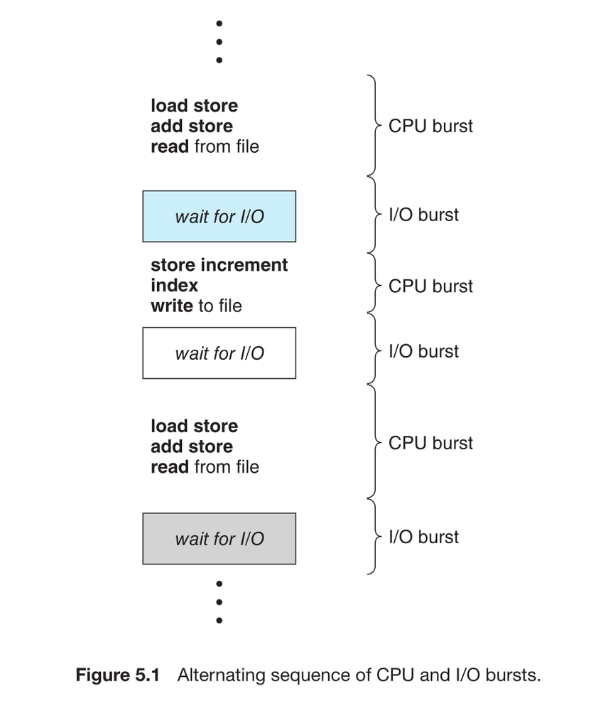

#### **The Importance of Burst Duration**

Extensive research has been done to measure the length of these CPU bursts. While the exact durations vary, they follow a predictable pattern, as shown in a frequency histogram.

*(You should refer to **Figure 5.2** in your text, which is a histogram showing the frequency of CPU-burst durations.)*

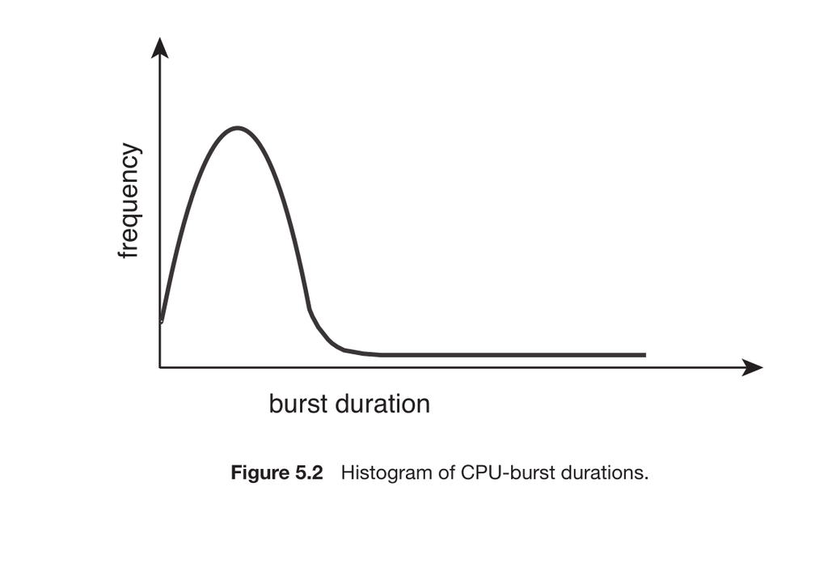

The curve in Figure 5.2 is crucial. It is **exponential or hyperexponential**, meaning:

- **There are a very large number of short CPU bursts.**
- **There are a relatively small number of long CPU bursts.**

This distribution is not just a curiosity; it has a direct impact on scheduling. We can categorize programs based on this pattern:

- **I/O-bound programs:** These programs spend most of their time waiting for I/O. When they get the CPU, they use it only briefly to set up the next I/O request. Therefore, they generate **many short CPU bursts**. Examples: a text editor, a web browser waiting for a click.
- **CPU-bound programs:** These programs spend most of their time performing intensive computations. They use the CPU for long, uninterrupted periods. Therefore, they generate **a few long CPU bursts**. Examples: a scientific calculation, compiling a large software project.

Understanding this mix of short and long bursts is vital for designing effective CPU-scheduling algorithms, as a good scheduler must handle both types of programs well.

### **5.1.2 CPU Scheduler**

#### **The Decision-Maker**

The **CPU scheduler** (often just called the **short-term scheduler**) is the part of the operating system that makes the critical decision of what to run next. Its job is triggered by a specific event: **whenever the CPU becomes idle**.

For example, the CPU becomes idle when:

- A running process terminates.
- A running process voluntarily gives up the CPU to wait for an I/O operation.
- An interrupt occurs.

At that moment, the scheduler must select one process from the **ready queue** and allocate the CPU to it.

#### **The Ready Queue**

The **ready queue** is the central list of all processes that are resident in memory, ready to execute, and waiting for the CPU.

Important points about the ready queue:

- **It's an Abstract Data Structure:** The ready queue is not necessarily a simple first-in, first-out (FIFO) line. Depending on the scheduling algorithm, it can be implemented as:
  - A **FIFO queue**
  - A **Priority queue**
  - A **Tree**
  - An **unordered linked list**
- **What's in the Queue?** The entries in the ready queue are typically the **Process Control Blocks (PCBs)** of the processes. The PCB is the kernel data structure that holds all the information the OS needs to manage a process (process state, program counter, CPU registers, etc.).

Conceptually, you can imagine all the ready processes lined up, and the CPU scheduler is the manager that picks the next one to run.

### **5.1.3 Preemptive and Nonpreemptive Scheduling**

#### **When Does Scheduling Happen?**

CPU-scheduling decisions are not random; they occur at specific, well-defined moments when a process changes its state. There are four such circumstances:

1. **Running → Waiting:** A process voluntarily gives up the CPU because it needs to wait for something (e.g., an I/O operation, or for another process to finish).
2. **Running → Ready:** A process is forcibly interrupted and moved back to the ready queue (e.g., when a timer interrupt occurs, or a higher-priority process becomes ready).
3. **Waiting → Ready:** A process finishes waiting (e.g., its I/O operation completes) and is moved back to the ready queue.
4. **Process Terminates:** A process finishes its execution and exits.

For circumstances **1 and 4**, the OS has **no choice**—the process is done using the CPU, so the scheduler *must* pick a new one from the ready queue.

For circumstances **2 and 3**, the OS *does* have a choice. It can either let the currently running process continue, or it can decide to switch to a different one. This choice defines the two main types of scheduling.

#### **Nonpreemptive Scheduling**

- **Definition:** Under **nonpreemptive** (or **cooperative**) scheduling, the scheduler only takes control during circumstances 1 and 4.
- **The Rule:** Once a process is given the CPU, it keeps it until it **voluntarily** releases it by terminating or by switching to the waiting state.
- **Analogy:** It's like having a meeting where a person holds the microphone and keeps it until they are finished speaking and hand it over.
- **Usage:** This method is simple but is largely obsolete for general-purpose OS cores. Virtually all modern operating systems (Windows, macOS, Linux, UNIX) use preemptive scheduling.

#### **Preemptive Scheduling**

- **Definition:** Under **preemptive** scheduling, the scheduler can take control during circumstances **2 and 3** as well.
- **The Rule:** The operating system can **forcibly** stop a currently running process, even if it is not finished, and give the CPU to another process.
- **Analogy:** It's like a debate moderator who can take the microphone away from one speaker to give it to another.
- **Usage:** This is the standard for all modern operating systems because it provides better system responsiveness and ensures that no single process can monopolize the CPU.

#### **The Challenges of Preemption**

Preemptive scheduling is powerful but introduces two major complications:

**1. Race Conditions on Shared Data:**

- **The Problem:** Imagine two processes sharing a variable. Process A is in the middle of updating the variable when it gets preempted. Process B then runs and reads the variable, but it reads an intermediate, inconsistent value because Process A didn't finish its update.
- **The Solution:** This problem requires **synchronization mechanisms** (like mutex locks and semaphores) to protect shared data. This is a central topic of **Chapter 6**.

**2. Design of the Operating-System Kernel:**

- **Nonpreemptive Kernel:** In this design, a process executing a system call in the kernel cannot be preempted until it finishes the call or blocks for I/O. This is simple and safe because kernel data structures cannot be left in an inconsistent state by a preemption. However, it is bad for **real-time computing** as it can cause long, unpredictable delays.
- **Preemptive Kernel:** In this design, a process can be preempted even while it is executing in the kernel. This is better for responsiveness and real-time systems but requires the kernel itself to be carefully written using synchronization mechanisms (like mutex locks) to protect all its internal data structures from concurrent access. **Most modern OS kernels are preemptive.**

**Handling Interrupts:** The text also notes that the kernel must handle interrupts carefully. To prevent corruption, small, critical sections of kernel code will temporarily **disable interrupts** at the start and **re-enable** them at the end. This ensures that a sequence of instructions that must run together is not interrupted. These sections are kept very short to avoid missing important hardware signals.

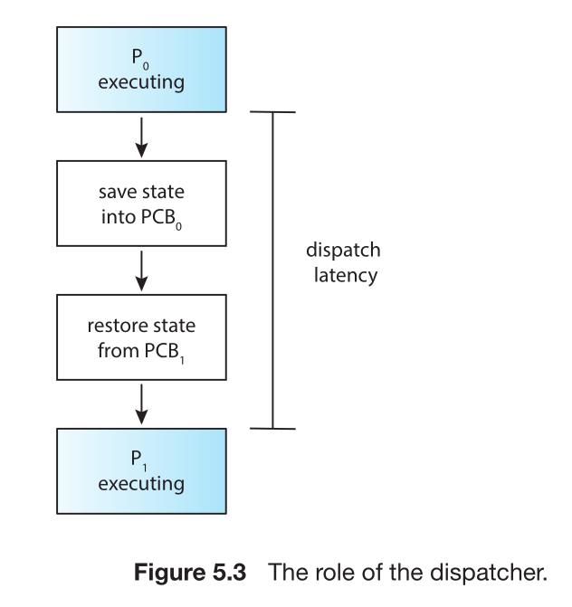

*(You should refer to **Figure 5.3** in your text, which illustrates the role of the dispatcher, the module that handles the actual context switch after the scheduler has made its decision.)*

### **5.1.4 Dispatcher**

#### **The "Switch" in Context Switching**

The **CPU Scheduler** is the brain that *decides* which process runs next. The **Dispatcher** is the muscle that carries out that decision. It is the kernel module responsible for actually transferring control of the CPU core to the newly selected process.

#### **The Dispatcher's Job Description**

When the dispatcher is activated, it performs a precise sequence of actions:

1. **Performing a Context Switch:**
   - It saves the state of the currently running process (like its program counter, CPU registers) into its **Process Control Block (PCB)**.
   - It loads the saved state of the new process from its PCB into the CPU registers and its program counter into the CPU's program counter register.
2. **Switching to User Mode:**
   - The CPU switches from privileged **kernel mode** (where the OS scheduler and dispatcher run) back to unprivileged **user mode**, where the user process will execute.
3. **Jumping to the User Program:**
   - Finally, the dispatcher jumps to the location in the user program that was saved in the program counter, resuming the program's execution exactly where it left off.

#### **Dispatch Latency: The Cost of Switching**

The time it takes for the dispatcher to complete this entire process—stopping one process and starting another—is called the **dispatch latency**.

*(You should refer to **Figure 5.3** in your text, which visually breaks down this latency.)*

**Why is this important?** The dispatcher is invoked during *every* process/thread switch. This time is pure overhead; the CPU is doing administrative work instead of running user programs. Therefore, the dispatcher must be engineered to be **extremely fast** to minimize this overhead and maximize useful CPU time.

#### **How Often Do Context Switches Occur?**

Context switching happens very frequently. The text shows how to measure this on a Linux system.

- **System-Wide View with `vmstat`:**
  - The command `vmstat 1` provides system statistics every second.
  - The `cs` column shows the number of context switches.
  - In the example, the system averaged 24 context switches per second since boot, with 225 and 339 context switches in two recent one-second intervals. This shows that context switching is a constant and heavy activity.
- **Per-Process View with `/proc`:**
  - You can examine the file `/proc/<PID>/status` for any running process.
  - This file shows two key statistics:
    - **voluntary_ctxt_switches:** This occurs when a process **gives up** the CPU itself, typically because it needs to wait for an I/O operation. (e.g., 150 times in the example).
    - **nonvoluntary_ctxt_switches:** This occurs when the OS **takes away** the CPU from the process, such as when its time quantum expires or a higher-priority process becomes ready. (e.g., 8 times in the example).

This distinction is crucial. A high number of voluntary switches often indicates an I/O-bound process, while a high number of nonvoluntary switches might indicate a CPU-bound process that the OS must preempt to be fair to others.

## **5.2 Scheduling Criteria**

#### **How Do We Judge a Scheduling Algorithm?**

Different CPU-scheduling algorithms have different strengths and weaknesses. To compare them objectively and decide which one is best for a given situation, we use a set of standard performance metrics. The choice of which metric to prioritize can completely change which algorithm is considered "best."

Here are the key criteria used for evaluation:

#### **The Five Key Metrics**

1. **CPU Utilization**
   - **What it is:** The percentage of time the CPU is busy doing useful work. We want to keep this as high as possible.
   - **Range:** Conceptually 0% to 100%. In a real system, it typically ranges from 40% (lightly loaded) to 90% (heavily used).
   - **How to measure:** You can use commands like `top` on Linux/macOS.
2. **Throughput**
   - **What it is:** The amount of work completed per unit of time. Specifically, it's the number of processes that finish their execution per second (or minute, etc.).
   - **Context Matters:** For long-running processes, throughput might be low (e.g., 1 process per second). For short transactions, it should be very high (e.g., 1000 processes per second).
3. **Turnaround Time**
   - **What it is:** The total time taken from when a process is submitted to the system until it finally completes. This is the process's perspective on its total lifetime in the system.
   - **Formula:** Turnaround Time = (Time of Completion) - (Time of Submission). It is the sum of all time spent waiting in the ready queue, executing on the CPU, and performing I/O.
4. **Waiting Time**
   - **What it is:** This is the specific amount of time a process spends waiting in the **ready queue**. The scheduling algorithm directly affects this metric.
   - **Crucial Point:** The scheduler has **no control** over how long a process needs to run on the CPU or perform I/O. Its only influence is on how long the process sits in line waiting for its turn. Therefore, minimizing waiting time is a primary goal of a good scheduler.
5. **Response Time**
   - **What it is:** This is specific to **interactive systems**. It is the time from when a request is submitted (e.g., the user presses 'Enter') until the system produces its **first response** (e.g., the first character appears on the screen). It measures how quickly the system starts to respond, not how long it takes to finish the task.
   - **Why it matters:** For a user, a system that starts responding immediately *feels* much faster, even if the total job takes the same amount of time.

#### **Optimization Goals and Nuances**

- **The General Rule:** We want to **maximize** CPU Utilization and Throughput, and **minimize** Turnaround Time, Waiting Time, and Response Time.
- **Average vs. Extreme Values:** We usually optimize for the **average** case (e.g., average waiting time). However, sometimes we care about the **worst** case. For example, to ensure fairness, we might want to minimize the *maximum* response time any user experiences.
- **The Importance of Predictability (Variance):** For interactive systems, a **predictable and consistent** response time is often more desirable than a faster but highly variable one. A system that usually responds in 0.1 seconds but sometimes takes 5 seconds feels sluggish and frustrating. Unfortunately, minimizing variance is a complex problem and not a primary focus of most common scheduling algorithms.

#### **A Note on Our Examples**

In the following sections, we will illustrate different scheduling algorithms with simplified examples. To keep things clear:

- We will represent each process by a single **CPU burst** time in milliseconds.
- Our primary metric for comparison will be the **average waiting time**.
- Remember that real processes have many alternating CPU and I/O bursts, and more complex evaluation methods (discussed in Section 5.8) are needed for a full analysis.

## **5.3 Scheduling Algorithms**

#### **Introduction to Scheduling Algorithms**

This section introduces the core algorithms that the CPU scheduler uses to solve its central problem: **deciding which process in the ready queue gets to use the CPU next.**

We will explore several different algorithms, each with its own strategy and characteristics. It's important to understand that the choice of algorithm has a direct and significant impact on the performance metrics we just learned about (waiting time, response time, etc.).

#### **A Note on the Scope of Our Discussion**

To keep the initial explanations clear and focused on the fundamental concepts, we will describe all these algorithms under a specific, simplified assumption:

- We are working with a system that has only **a single CPU with a single core**.
- This means the system is physically capable of running **only one process at a single point in time**.

This single-core model allows us to understand the pure logic of each algorithm without the added complexity of managing multiple cores simultaneously. Later, in **Section 5.5**, we will expand this discussion to cover the more complex scheduling issues that arise in **multiprocessor and multicore systems**.

### **5.3.1 First-Come, First-Served (FCFS) Scheduling**

#### **The Simplest Algorithm**

The **First-Come, First-Served (FCFS)** scheduling algorithm is the most straightforward approach. The rule is simple: the process that requests the CPU first is the one that gets it first.

- **Implementation:** It is easily managed with a **First-In, First-Out (FIFO) queue**.
  1. When a process enters the ready queue, its PCB is added to the **tail** of the queue.
  2. When the CPU becomes free, it is allocated to the process at the **head** of the queue.
  3. That process is then removed from the queue.
- **Advantage:** The algorithm is very simple to code and understand.

#### **The Problem: Poor Average Waiting Time**

The main disadvantage of FCFS is that it can lead to very long **average waiting times**, especially when the order of process arrival is unlucky.

Let's analyze an example with three processes arriving at time 0:

| Process | Burst Time (ms) |
| --- | --- |
| P1 | 24 |
| P2 | 3 |
| P3 | 3 |

**Scenario 1: Order P1, P2, P3**

The Gantt chart (a bar chart showing the schedule) would look like this:

```
|---- P1 -----|-- P2 --|- P3 -|
0             24       27     30
```

- **Waiting Times:**
  - P1: 0 ms (runs immediately)
  - P2: 24 ms (waits for P1 to finish)
  - P3: 27 ms (waits for P1 and P2 to finish)
- **Average Waiting Time:** (0 + 24 + 27) / 3 = **17 ms**

**Scenario 2: Order P2, P3, P1**

Now, let's see what happens if the shorter processes arrive first:

```
|-- P2 --|- P3 -|---- P1 -----|
0        3      6             30
```

- **Waiting Times:**
  - P2: 0 ms
  - P3: 3 ms
  - P1: 6 ms
- **Average Waiting Time:** (0 + 3 + 6) / 3 = **3 ms**

This demonstrates a massive improvement just by changing the order. The key takeaway is that **FCFS can result in a very high average waiting time, which is not minimal and is highly dependent on the arrival order of processes.**

#### **The Convoy Effect**

FCFS can cause a serious performance problem known as the **convoy effect**.

- **The Situation:** Imagine one **CPU-bound** process (with a long CPU burst) and many **I/O-bound** processes (with very short CPU bursts).
- **What Happens:**
  1. The CPU-bound process gets the CPU and holds it for a long time.
  2. Meanwhile, all the I/O-bound processes finish their I/O quickly and enter the ready queue, where they are stuck waiting for the long process.
  3. During this wait, the now-idle **I/O devices are unused**.
  4. Finally, the CPU-bound process finishes and moves to an I/O device. Now the short processes quickly run through their CPU bursts and go back to I/O.
  5. This leaves the **CPU idle** until the long CPU-bound process finishes its I/O and gets the CPU again.
- **The Result:** The short processes are "convoyed" behind the slow, long process, leading to low **both CPU and I/O device utilization**.

#### **Nonpreemptive Nature**

The FCFS algorithm is **nonpreemptive**. Once a process gets the CPU, it keeps it until it voluntarily terminates or blocks for I/O.

- **Consequence for Interactive Systems:** This makes FCFS **terrible for interactive systems**. Allowing one process to hold the CPU for an extended period would make the entire system feel unresponsive, as no other process could run until the current one decided to yield.

### **5.3.2 Shortest-Job-First (SJF) Scheduling**

#### **The Core Idea**

The **Shortest-Job-First (SJF)** scheduling algorithm selects the process with the smallest next CPU burst. When the CPU becomes available, it is assigned to the process that has the **shortest upcoming CPU burst**.

- **Tie-breaking:** If two processes have the same next CPU burst length, **First-Come, First-Served (FCFS)** scheduling is used to break the tie.
- **Important Terminology Note:** A more accurate name for this algorithm would be "Shortest-*Next*-CPU-Burst" scheduling, as the decision is based solely on the length of the *next* burst from the process, not the total job length. However, the term SJF is universally used.

#### **Nonpreemptive SJF Example and Optimality**

Consider the following set of processes arriving at time 0:

| Process | Burst Time (ms) |
| --- | --- |
| P1 | 6 |
| P2 | 8 |
| P3 | 7 |
| P4 | 3 |

Using **nonpreemptive SJF**, the scheduler will pick the process with the shortest burst first. The resulting Gantt chart is:

```
|- P4 -|- P1 -|- P3 -|-- P2 --|
0      3      9      16       24
```

- **Waiting Time Calculation:**
  - P1: 3 ms (waits for P4)
  - P2: 16 ms (waits for P4, P1, and P3)
  - P3: 9 ms (waits for P4 and P1)
  - P4: 0 ms (runs immediately)
- **Average Waiting Time:** (3 + 16 + 9 + 0) / 4 = **7.0 milliseconds**

For comparison, the text states that FCFS would yield an average waiting time of 10.25 ms, confirming SJF's superiority here.

**Optimality:** The SJF scheduling algorithm is **provably optimal** for minimizing the *average waiting time* for a given set of processes. The reason is that moving a short process before a long one decreases the short process's waiting time more than it increases the long process's waiting time, thereby reducing the overall average.

#### **The Major Problem: Implementation**

Although SJF is optimal, it has a critical flaw: **there is no way to know the exact length of the next CPU burst** for a process. This makes it impossible to implement a perfect SJF scheduler at the CPU scheduling level.

**The Solution: Predicting the Next CPU Burst**

Since we cannot know the future, we try to **predict** it. The assumption is that a process's next CPU burst will be similar in length to its previous ones. We use the **Exponential Average (or Aging)** method to calculate this prediction.

**The Exponential Average Formula:**

Let:

- ( t_n ) = actual length of the *n*th CPU burst
- ( τ_{n+1} ) = predicted value for the *next* CPU burst
- ( α ) = smoothing parameter, where ( 0 ≤ α ≤ 1 )

The formula is:

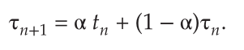

**How the Formula Works:**

- ( t_n ) represents the most recent, actual measurement.
- ( τ_n ) stores the entire past history of predictions and measurements.
- The parameter ( α ) controls the weight given to recent history versus past history.
  - If ( α = 0 ), then ( τ_{n+1} = τ_n ). Recent history has no effect; the prediction is unchanged.
  - If ( α = 1 ), then ( τ_{n+1} = t_n ). Only the most recent CPU burst matters; all past history is ignored.
  - Commonly, ( α = 1/2 ), giving equal weight to recent and past history.

*(You should refer to **Figure 5.4** in your text, which shows a specific example of this prediction calculation with α=1/2 and an initial guess τ₀=10.)*

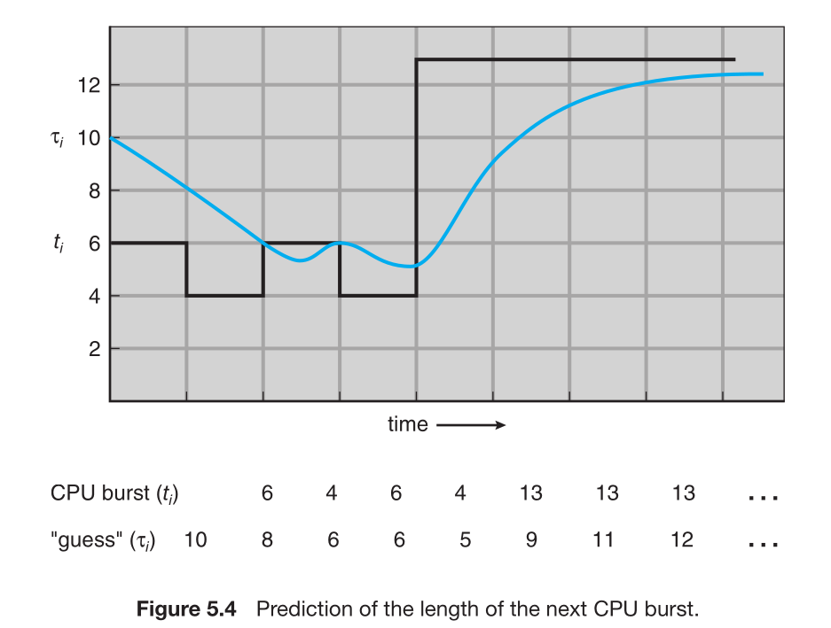

The expanded form of the formula shows that each successive term in the history has less weight than its predecessor, which is why it's called an "exponential" average.

#### **Preemptive SJF (Shortest-Remaining-Time-First)**

SJF can be implemented in a **preemptive** version. This is called **Shortest-Remaining-Time-First (SRTF)** scheduling.

- **The Rule:** When a new process arrives in the ready queue, its CPU burst time is compared to the **remaining CPU burst time** of the currently executing process. If the new process has a shorter burst, the current process is **preempted**.

**Preemptive SJF Example:**

Consider these processes with arrival times:

| Process | Arrival Time | Burst Time (ms) |
| --- | --- | --- |
| P1 | 0 | 8 |
| P2 | 1 | 4 |
| P3 | 2 | 9 |
| P4 | 3 | 5 |

The resulting **preemptive SJF (SRTF)** schedule is depicted in the following Gantt chart:

```
|- P1 -|- P2 -|- P4 -|-- P1 --|---- P3 ----|
0      1      5      10       17           26
```

**Step-by-Step Explanation:**

1. **Time 0:** Only P1 is present, so it starts.
2. **Time 1:** P2 arrives. P1 has 7ms remaining. P2 has a burst of 4ms, which is shorter. P1 is **preempted**, and P2 starts.
3. **Time 2:** P3 arrives. P2 has 3ms remaining. P3 has a burst of 9ms, which is longer. P2 continues.
4. **Time 3:** P4 arrives. P2 has 2ms remaining. P4 has a burst of 5ms, which is longer. P2 continues until it finishes at time 5.
5. **Time 5:** Now we check the ready queue: P1 (7ms remaining), P3 (9ms), P4 (5ms). The shortest remaining time is P4 (5ms), so P4 runs.
6. **Time 10:** P4 finishes. The shortest remaining time is now P1 (7ms), so P1 resumes.
7. **Time 17:** P1 finishes. The only process left is P3 (9ms), so it runs to completion.

**Waiting Time Calculation:**

- P1: Started at 0, preempted at 1, resumed at 10, finished at 17. Total waiting time = (Time started waiting) = (1-1) for first preemption is not waiting, it's running. Let's calculate correctly: **P1's waiting time** is from arrival until it first runs (0ms) plus the time it spends ready after being preempted (from time 1 to time 10 = 9ms). So total = 9ms. Alternatively, use the formula: (Finish Time - Arrival Time - Burst Time) = (17 - 0 - 8) = **9ms**.
- P2: (Finish Time - Arrival Time - Burst Time) = (5 - 1 - 4) = **0ms**.
- P3: (26 - 2 - 9) = **15ms**.
- P4: (10 - 3 - 5) = **2ms**.
- **Average Waiting Time:** (9 + 0 + 15 + 2) / 4 = **26/4 = 6.5 milliseconds**
- The key point is that preemptive SJF provides a lower average waiting time than the nonpreemptive version, which was 7.75 ms.

### **5.3.3 Round-Robin (RR) Scheduling**

#### **The Core Idea: FCFS with Preemption**

The **Round-Robin (RR)** scheduling algorithm is designed especially for time-sharing systems. It is similar to FCFS but adds **preemption** to ensure fairness.

- **The Mechanism:** A small unit of time, called a **time quantum** or **time slice**, is defined. This is typically between **10 and 100 milliseconds**.
- **The Ready Queue:** The ready queue is treated as a **circular FIFO queue**.
- **The Rule:** The CPU scheduler goes around the ready queue, allocating the CPU to each process for a maximum of **one time quantum**.

#### **How RR Scheduling is Implemented**

The implementation works as follows:

1. The CPU scheduler picks the first process from the ready queue.
2. It sets a **timer** to interrupt after one time quantum.
3. It **dispatches** the process.

One of two things then happens:

- **Scenario A: The process finishes before the quantum.**
  - If the process's CPU burst is shorter than the time quantum, it will **voluntarily** release the CPU by terminating or blocking for I/O before the timer goes off.
  - The scheduler then simply proceeds to the next process in the ready queue.
- **Scenario B: The process does not finish.**
  - If the process's CPU burst is longer than the time quantum, the **timer will interrupt** the process when the quantum expires.
  - The OS performs a **context switch** and puts the interrupted process at the **tail** of the ready queue.
  - The CPU scheduler then selects the next process from the head of the queue.

#### **RR Scheduling Example**

Consider the following processes arriving at time 0:

| Process | Burst Time (ms) |
| --- | --- |
| P1 | 24 |
| P2 | 3 |
| P3 | 3 |

Using a **time quantum of 4 ms**, the resulting RR schedule is:

```
|- P1 -|- P2 -|- P3 -|- P1 -|- P1 -|- P1 -|- P1 -|- P1 -|
0      4      7      10     14     18     22     26     30
```

**Waiting Time Calculation:**

**Average Waiting Time:** (6 (P1) + 4 (P2) + 7 (P3)) / 3 = **17/3 = 5.66 milliseconds**.

#### **Key Properties of RR**

- **Preemptive:** RR is inherently preemptive because processes are interrupted at the end of their time quantum.
- **Fairness Guarantee:** If there are `n` processes in the ready queue and the time quantum is `q`, then each process gets `1/n` of the CPU time in chunks of at most `q` time units. No process has to wait for more than `(n-1) * q` time units to get its next turn.

#### **The Critical Factor: Time Quantum Size**

The performance of RR depends almost entirely on the size of the time quantum.

- **Very Large Quantum:** If the time quantum is extremely large (e.g., larger than the longest CPU burst), RR **degenerates into FCFS**. A process will finish its entire CPU burst in one quantum.
- **Very Small Quantum:** If the time quantum is extremely small (e.g., 1 ms), the system suffers from a very **high rate of context switches**.

*(You should refer to **Figure 5.5** in your text, which shows how a process with a burst of 10 requires more context switches as the time quantum decreases.)*

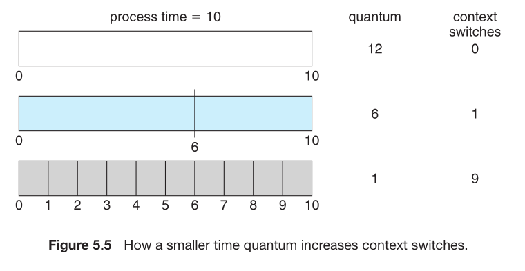

- **Overhead:** If the context-switch time is about 10% of the time quantum, then a full 10% of CPU time is wasted on overhead. This is unacceptable.
- **Practice:** In practice, context-switch time is usually less than 10 microseconds, and time quanta are 10-100 ms, so the context-switch overhead is a very small fraction (about 0.1%) of the quantum.

#### **Effect on Turnaround Time**

*(You should refer to **Figure 5.6** in your text, which shows the relationship between time quantum size and average turnaround time.)*

The average turnaround time does not always improve as the time quantum increases.

- **Example:** With three processes, each with a 10ms burst:
  - If the quantum is 1ms, the average turnaround time is high (29ms) due to many context switches.
  - If the quantum is 10ms, the average turnaround time drops to 20ms, as each process finishes in one shot.

**The Rule of Thumb:** The time quantum should be:

1. **Large compared to the context-switch time** to keep overhead low.
2. **Not so large that it behaves like FCFS.**
3. A good guideline is that **80% of CPU bursts should be shorter than the time quantum**. This allows most processes to finish their burst in a single quantum, minimizing preemption and context switches while maintaining good response times.

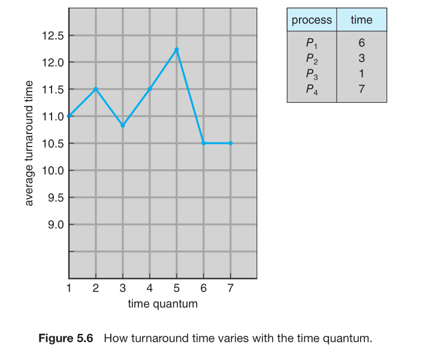

### **5.3.5 Multilevel Queue Scheduling**

#### **The Concept: Separating Processes into Classes**

The previous algorithms assumed all processes were in a single queue. **Multilevel Queue Scheduling** recognizes that different types of processes have different needs. It partitions the ready queue into several separate queues, each with its own scheduling algorithm.

#### **Multilevel Queue for Priorities**

This approach is a natural extension of priority scheduling. Instead of having one queue where the scheduler must search for the highest-priority process (an O(n) operation), we create a separate queue for each priority level.

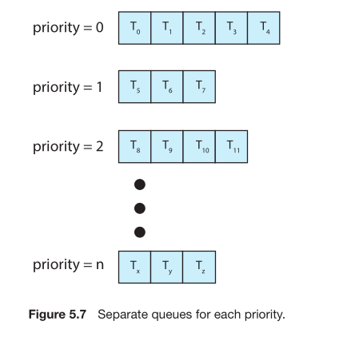

*(You should refer to **Figure 5.7** in your text, which illustrates separate queues for each priority level, with threads T0-Tz in their respective queues.)*

- **How it works:** The scheduler always runs a process from the **highest-priority, non-empty queue**.
- **Scheduling within a queue:** If there are multiple processes in the highest-priority queue, they can be scheduled using another algorithm, most commonly **Round-Robin (RR)**.
- **Fixed Priority:** In this simple scheme, a process is assigned a priority **statically** (at creation) and remains in the same queue for its entire lifetime.

#### **Multilevel Queue for Process Types**

A more common use of multilevel queue scheduling is to partition processes based on their **type or purpose**, as each type has different response-time requirements.

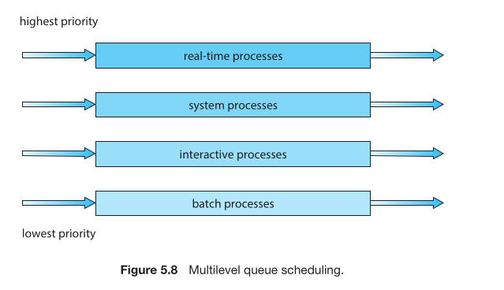

*(You should refer to **Figure 5.8** in your text, which shows a common multilevel queue system with queues for real-time, system, interactive, and batch processes.)*

A typical division includes these queues, listed from highest to lowest priority:

1. **Real-time Processes:** Require immediate attention to meet deadlines.
2. **System Processes:** OS-level processes that must be responsive.
3. **Interactive Processes:** User-facing applications (editors, shells) that need good response time.
4. **Batch Processes:** Background jobs (compilers, scientific calculations) that have no strict timing needs.

Each of these queues can use the scheduling algorithm best suited to its process type. For example:

- The **foreground (interactive)** queue might use **RR scheduling** to ensure good response time.
- The **background (batch)** queue might use **FCFS scheduling** because throughput is more important than response time.

#### **Scheduling Between the Queues**

Now that we have multiple queues, we need a meta-scheduler to decide how to allocate the CPU *between* them. There are two primary methods:

**1. Fixed-Priority Preemptive Scheduling (Most Common)**

- **The Rule:** Each queue has an absolute, fixed priority. The scheduler always runs processes from the **highest-priority non-empty queue**.
- **Preemption:** If a process enters a higher-priority queue while a lower-priority process is running, the lower-priority process is **immediately preempted**.
- **Example:** In the 4-queue system above, no batch process (queue 4) could run unless the real-time, system, and interactive queues (1, 2, and 3) were all empty. If an interactive process becomes ready while a batch process is running, the batch process is preempted.

**2. Time Slicing Between Queues**

- **The Rule:** Each queue gets a predefined percentage of the total CPU time.
- **Example:** In a foreground-background system:
  - The **foreground (interactive)** queue gets **80%** of the CPU time and schedules its processes using RR.
  - The **background (batch)** queue gets **20%** of the CPU time and schedules its processes using FCFS.
- This method prevents starvation of lower-priority queues but may not provide the strict prioritization that some system processes require.

### **5.3.6 Multilevel Feedback Queue Scheduling**

#### **The Concept: Dynamic and Adaptive Queues**

The standard Multilevel Queue scheduler is inflexible because processes are permanently assigned to a queue. The **Multilevel Feedback Queue** algorithm is a more sophisticated and adaptive approach that **allows processes to move between queues** based on their observed behavior. The core idea is to automatically separate processes according to the actual characteristics of their CPU bursts.

#### **How It Works: The Core Principles**

The algorithm is designed to achieve two main goals:

1. **Favor Short Bursts (I/O-bound and Interactive Processes):** If a process uses too much CPU time in one go, it is **moved to a lower-priority queue**. This leaves processes with short CPU bursts (like I/O-bound and interactive ones) in the higher-priority queues where they get quick service.
2. **Prevent Starvation:** A process that waits too long in a lower-priority queue may be **moved to a higher-priority queue**. This technique, called **aging**, ensures that no process is permanently ignored.

#### **A Detailed Example**

Consider a multilevel feedback queue scheduler with three queues (Q0, Q1, Q2), as shown in the figure.

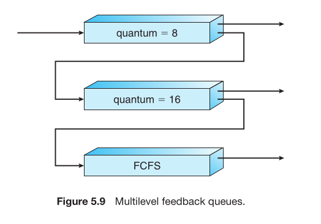

*(You should refer to **Figure 5.9** in your text, which illustrates this 3-queue system with their respective time quanta.)*

Here are the rules for this specific example:

- **Queue 0:** Highest priority. Uses **Round-Robin** with a **time quantum of 8 ms**.
- **Queue 1:** Medium priority. Uses **Round-Robin** with a **time quantum of 16 ms**.
- **Queue 2:** Lowest priority. Uses **FCFS** scheduling.

**The Scheduling and Migration Rules:**

1. **Initial Placement:** A new process is always placed in the highest-priority queue, **Queue 0**.
2. **Execution Order:** The scheduler always runs all processes in **Q0**. Only when Q0 is empty will it run processes in **Q1**. Only when both Q0 and Q1 are empty will it run processes in **Q2**.
3. **Preemption:** A process entering Q0 will preempt a process running from Q1 or Q2. Similarly, a process entering Q1 will preempt a process running from Q2.
4. **Demotion (Moving Down):**
   - If a process in **Q0** does not finish its CPU burst within its 8 ms time quantum, it is **preempted and moved to the tail of Q1**.
   - If a process in **Q1** does not finish its CPU burst within its 16 ms time quantum, it is **preempted and moved to the tail of Q2**.
5. **Promotion (Moving Up - Aging):** To prevent starvation, any process that waits too long in **Q1** or **Q2** may be gradually moved up to a higher queue.

**What This Achieves:**

- Processes with CPU bursts of **8 ms or less** will finish quickly in Q0 and get the best response time.
- Processes needing between **8 and 24 ms** will be served quickly in Q0 and Q1, but with slightly lower priority.
- Long, **CPU-bound processes** will automatically sink to **Q2**, where they are run in the background with whatever CPU time is left over from the higher-priority queues.

#### **The General Parameters of a Multilevel Feedback Queue**

This algorithm is the most general and configurable of all the scheduling methods. To define a specific multilevel feedback queue scheduler, you must specify these parameters:

1. **The number of queues.**
2. **The scheduling algorithm for each queue** (e.g., RR, FCFS).
3. **The method used to determine when to upgrade a process** to a higher-priority queue (e.g., after waiting for a certain duration to implement aging).
4. **The method used to determine when to demote a process** to a lower-priority queue (e.g., if it uses up its time quantum).
5. **The method used to determine which queue a process will enter** when that process needs service (e.g., all new processes start in the highest queue).

#### **Advantages and Disadvantages**

- **Advantage:** It is the most flexible and adaptive algorithm. It can be tuned to match a specific system's workload perfectly, automatically favoring short jobs while preventing starvation.
- **Disadvantage:** It is the **most complex algorithm**. There is no single "best" configuration; finding the right set of parameters (number of queues, time quanta, promotion/demotion rules) for a given system is a difficult design problem.

## **5.4 Thread Scheduling**

#### **Recap: User and Kernel Threads**

As introduced in Chapter 4, operating systems distinguish between user-level and kernel-level threads.

- **Kernel-Level Threads:** These are the entities that the **operating system kernel schedules** onto CPU cores. The kernel is aware of and manages them directly.
- **User-Level Threads:** These are managed entirely by a **thread library** within a user process. The kernel is **unaware** of their existence.

For a user-level thread to run on a CPU, it must be mapped to a kernel-level thread, often through an intermediary called a **Lightweight Process (LWP)**. This mapping leads to two different scopes of scheduling competition.

### **5.4.1 Contention Scope**

The concept of **Contention Scope** defines the pool of threads that compete with each other for CPU resources. There are two distinct scopes:

#### **1. Process-Contention Scope (PCS)**

- **When it is used:** This scheduling occurs in systems using the **many-to-one** and **many-to-many** multithreading models.
- **Who does the scheduling:** The **user-level thread library** (not the OS kernel) performs PCS scheduling.
- **What it does:** The thread library decides which of its **user-level threads** gets to run on an available **LWP**.
- **The Competition Pool:** Competition for the CPU happens **only among threads belonging to the same process**. Threads from one process do not compete with threads from another process at this level.

**Important Clarification:** When a thread library schedules a user thread onto an LWP, that thread is not yet running on a CPU. It simply now has a "vehicle" (the LWP and its associated kernel thread) that can be scheduled by the OS. The OS must then schedule that kernel thread onto a physical CPU core using SCS.

**How PCS Scheduling Works:**

- It is typically **priority-based**. The thread library selects the runnable user-level thread with the highest priority.
- These priorities are usually set by the programmer and not adjusted by the library.
- PCS is usually **preemptive**: a higher-priority thread will preempt a lower-priority one.
- However, there is **typically no time slicing (Round-Robin) among threads of equal priority** within PCS. If a thread with equal priority is running, it may run indefinitely unless it voluntarily yields.

#### **2. System-Contention Scope (SCS)**

- **When it is used:** This scheduling is performed by the **operating system kernel**.
- **What it does:** The kernel decides which **kernel-level thread** (from any process in the system) gets to run on a physical CPU core.
- **The Competition Pool:** Competition for the CPU happens among **all threads in the entire system**. A thread from one process competes directly with threads from all other processes.

Systems that use the **one-to-one** threading model (like Windows and Linux) schedule threads **using only SCS**. In these systems, every user-level thread is mapped directly to a kernel thread, so the kernel has full visibility and control over all threads, making PCS scheduling by a thread library unnecessary.

### **5.4.2 Pthread Scheduling**

#### **Contention Scope in the Pthreads API**

The POSIX Pthreads standard provides an API that allows a programmer to explicitly specify the **contention scope** for a thread when it is created. This gives the programmer control over whether a thread is scheduled via PCS or SCS.

The two defined contention scope values are:

- **`PTHREAD_SCOPE_PROCESS`:** Schedules the thread using **Process-Contention Scope (PCS)**.
- **`PTHREAD_SCOPE_SYSTEM`:** Schedules the thread using **System-Contention Scope (SCS)**.

#### **How Contention Scope Affects Thread Mapping**

The effect of choosing a scope depends on the underlying threading model supported by the operating system:

- **On systems using the many-to-many model:**
  - `PTHREAD_SCOPE_PROCESS`: The thread library will schedule the user-level thread onto one of a pool of available **Lightweight Processes (LWPs)**. The number of LWPs is managed by the thread library, potentially using a technique like **scheduler activations** (see Section 4.6.5).
  - `PTHREAD_SCOPE_SYSTEM`: This policy will **create and bind a dedicated LWP** for the user-level thread. This effectively **maps the thread using the one-to-one policy**, making it directly visible to and scheduled by the OS kernel.
- **On systems using the one-to-one model (like Linux and macOS):**
  - The `PTHREAD_SCOPE_SYSTEM` policy is used by default and is often the **only allowed value**. Since every user thread is already a kernel thread, there is no separate PCS scheduling; all scheduling is done by the kernel at the system scope.

#### **The Pthreads API Functions**

Pthreads provides two main functions for managing the contention scope attribute of a thread:

1. **`pthread_attr_setscope(pthread_attr_t *attr, int scope)`**
   - **Purpose:** Sets the contention scope in a thread attribute object.
   - **Parameters:**
     - `attr`: A pointer to the thread attribute set.
     - `scope`: The desired scope, either `PTHREAD_SCOPE_SYSTEM` or `PTHREAD_SCOPE_PROCESS`.
   - **Return Value:** Returns 0 on success, and a nonzero error code on failure.
2. **`pthread_attr_getscope(pthread_attr_t *attr, int *scope)`**
   - **Purpose:** Retrieves the current contention scope from a thread attribute object.
   - **Parameters:**
     - `attr`: A pointer to the thread attribute set.
     - `scope`: A pointer to an integer where the current scope value will be stored.
   - **Return Value:** Returns 0 on success, and a nonzero error code on failure.

#### **Code Example Breakdown**

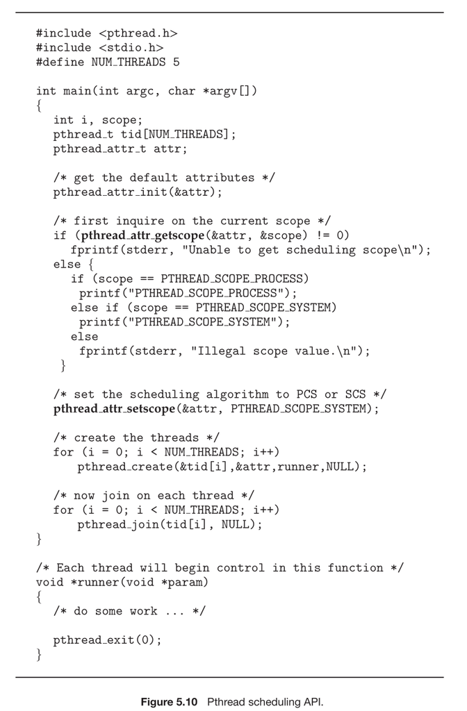

The provided program demonstrates how to use the Pthread scheduling API:

1. **Initialization:** It first gets the default thread attributes using `pthread_attr_init()`.
2. **Inquiry:** It checks the current default scheduling scope using `pthread_attr_getscope()` and prints out whether it is `PTHREAD_SCOPE_PROCESS` or `PTHREAD_SCOPE_SYSTEM`.
3. **Setting the Scope:** It sets the scheduling scope in the attribute object to `PTHREAD_SCOPE_SYSTEM` using `pthread_attr_setscope()`. This means any thread created with this attribute will be bound to its own LWP and scheduled directly by the OS kernel.
4. **Thread Creation:** It creates five threads using `pthread_create()`, passing the modified attribute object (`&attr`) to ensure they are all created with the SCS policy.
5. **Waiting and Execution:** The main thread waits for all created threads to finish using `pthread_join()`. Each thread begins execution in the `runner()` function.

**Important Note:** The text reminds us that on some systems, like Linux and macOS, only `PTHREAD_SCOPE_SYSTEM` is allowed. Attempting to set `PTHREAD_SCOPE_PROCESS` on these systems would result in an error.

## **5.5 Multi-Processor Scheduling**

#### **Introduction: From Single-Core to Multi-Core**

Our discussion so far has assumed a system with a single CPU core. When multiple processing units are available, **load sharing**—running multiple threads in parallel—becomes possible. However, scheduling becomes significantly more complex, and there is no single "best" solution.

The definition of a "multiprocessor" has evolved. Traditionally, it meant multiple physical CPUs, each with a single core. On modern systems, it encompasses:

- **Multicore CPUs:** A single chip with multiple processing cores.
- **Multithreaded cores:** Cores that can execute multiple threads simultaneously (e.g., Intel's Hyper-Threading).
- **NUMA systems:** Non-Uniform Memory Access systems, where memory access times depend on the memory location relative to the processor.
- **Heterogeneous multiprocessing:** Systems where the processors are not identical (e.g., ARM's big.LITTLE, with high-power and low-power cores).

We will first focus on **homogeneous** systems, where all processors are functionally identical, so any process can run on any CPU. Later, we will cover heterogeneous systems.

### **5.5.1 Approaches to Multiple-Processor Scheduling**

There are two primary architectural approaches to organizing the scheduler in a multiprocessor system.

#### **1. Asymmetric Multiprocessing (ASMP)**

- **The Idea:** All scheduling decisions, I/O processing, and other system activities are handled by a single, designated processor—the **master server**. The other processors only execute user code.
- **Advantage:** **Simplicity.** Only one core accesses the system data structures (like the ready queue), which drastically reduces the complexity of sharing data and the need for locking.
- **Disadvantage:** The master server becomes a **performance bottleneck**. If the master is overloaded, the entire system's performance suffers, as all other processors must wait for scheduling decisions.

#### **2. Symmetric Multiprocessing (SMP) - The Standard Approach**

- **The Idea:** Each processor is **self-scheduling**. Every core independently runs its own scheduler, which examines the ready queue and selects a thread to run.
- **Prevalence:** This is the standard approach used by virtually all modern operating systems (Windows, Linux, macOS, Android, iOS).

Within SMP, there are two main strategies for organizing the threads that are eligible to be scheduled:

**(A) Common Ready Queue (Shared Queue)**

- **Description:** All threads are placed in a **single, shared ready queue** that all processors access.
- **Challenge: Race Conditions.** We must ensure that two different processors do not select the same thread to run, and that threads are not lost from the queue. This requires **locking** mechanisms (covered in Chapter 6).
- **Problem:** The lock protecting the shared queue can become a **high-contention bottleneck**, as every processor must acquire it to select a thread, slowing down the entire scheduling process.

**(B) Per-Processor Run Queues (Private Queues)**

- **Description:** Each processor has its **own private queue** of threads. A processor only schedules threads from its own queue.
- **Advantage:** **No contention.** Since each processor manages its own queue, no complex locking is needed for thread selection, avoiding the bottleneck of a shared queue.
- **Additional Benefit:** This can lead to more efficient use of **cache memory** (as discussed in Section 5.5.4), because a thread is more likely to be re-scheduled on the same processor, reusing data that may still be in that processor's cache.
- **Challenge:** **Load Imbalance.** One processor's queue might be empty while another's is full. To solve this, **load balancing algorithms** are used to migrate threads between queues to equalize the workload.

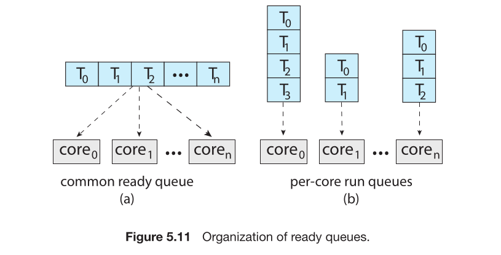

**Conclusion:** Due to the performance benefits, **SMP with per-processor run queues** is the most common approach in modern operating systems.

### **5.5.2 Multicore Processors**

#### **From Multiple CPUs to Multiple Cores**

Traditionally, SMP systems used multiple physical processor chips to achieve parallelism. Now, the standard is the **multicore processor**: a single physical chip that contains multiple independent computing **cores**. Each core maintains its own architectural state (registers, etc.), so the operating system sees each core as a separate logical CPU. This is faster and more power-efficient than using multiple single-core chips.

#### **The Problem: Memory Stalls**

Multicore processors introduce a scheduling complication related to memory speed.

- **The Memory Stall:** Processors run much faster than memory. When a core needs data that isn't in its local cache (a **cache miss**), it must wait for the data to be fetched from main memory. This waiting period is called a **memory stall**. A processor can spend up to **50% of its time stalled**, waiting for data.

*(You should refer to **Figure 5.12** in your text, which illustrates a compute cycle followed by a memory stall cycle.)*

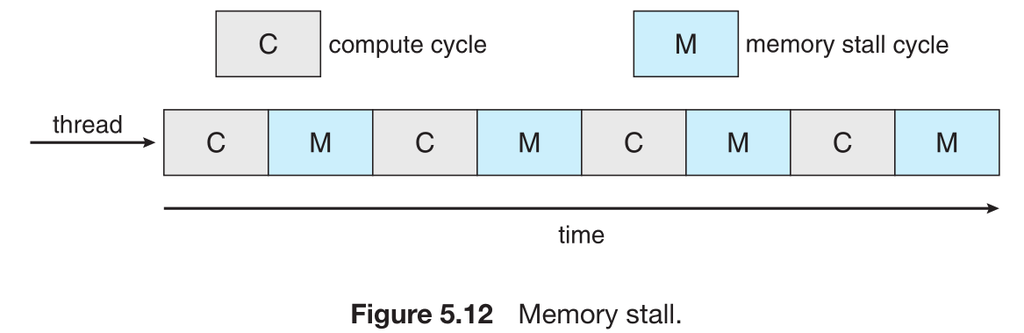

#### **The Hardware Solution: Multithreaded Cores**

To keep cores busy during memory stalls, hardware designers created **multithreaded cores**. In this design, two or more **hardware threads** are assigned to a single core. Each hardware thread has its own architectural state (instruction pointer, register set), so it appears to the OS as a separate logical CPU.

- **How it works:** If one hardware thread stalls waiting for memory, the core can immediately switch to executing another hardware thread that is ready to run. This technique is known as **Chip Multithreading (CMT)** or, in Intel's terminology, **Hyper-Threading** or **Simultaneous Multithreading (SMT)**.

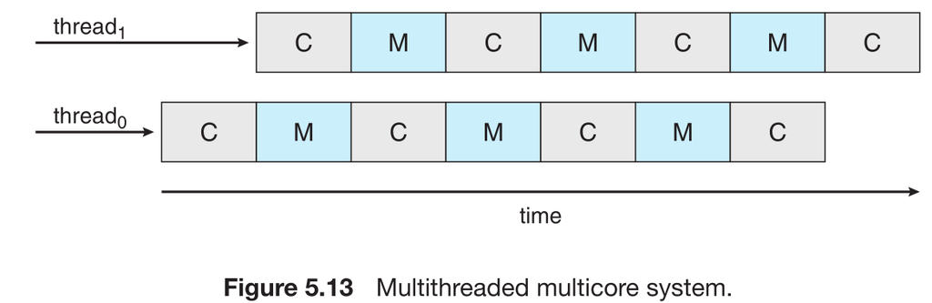

*(You should refer to **Figure 5.13** in your text, which shows how the execution of two threads is interleaved on a single core to hide memory stalls.)*

**Example:** A processor with 4 cores, each supporting 2 hardware threads, provides the operating system with **8 logical CPUs** to schedule.

*(You should refer to **Figure 5.14** in your text, which illustrates this mapping from physical cores and hardware threads to the OS's view of logical CPUs.)*

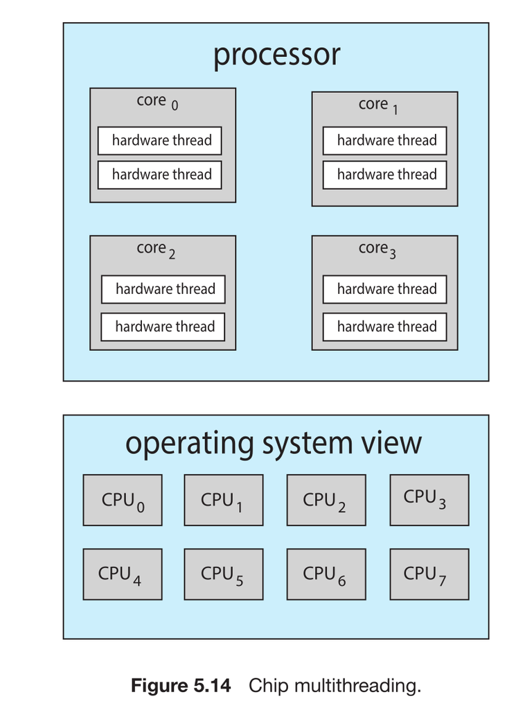

#### **Types of Multithreading**

There are two primary ways to implement hardware multithreading:

1. **Coarse-Grained Multithreading:**
   - A thread executes on a core until a **long-latency event** (like a memory stall) occurs.
   - The core then switches to another thread.
   - **Disadvantage:** The cost of switching is high because the core's **instruction pipeline must be flushed**, causing a significant delay.
2. **Fine-Grained (Interleaved) Multithreading:**
   - Switching between threads happens at a much finer granularity, often at the boundary of an instruction cycle.
   - The core has built-in logic to handle this frequent switching, so the **cost of switching between threads is very low**.

#### **The Two Levels of Scheduling**

Multithreaded cores create a hierarchy that requires **two different levels of scheduling**.

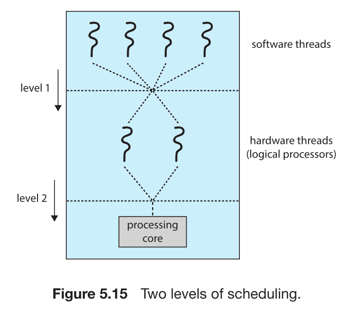

*(You should refer to **Figure 5.15** in your text, which illustrates these two levels.)*

**Level 1: Operating System Scheduling (Software Threads -> Hardware Threads)**

- This is the scheduling we have been discussing all chapter.
- The OS scheduler decides which **software thread** to assign to each **hardware thread** (logical CPU).
- The OS can use any algorithm (RR, Priority, etc.) for this decision.

**Level 2: Core Scheduling (Hardware Threads -> Physical Core)**

- This is done by the **processor core itself**.
- The core must decide which of its assigned hardware threads gets to use the core's execution resources at any given moment.
- **Strategies vary by processor:**
  - **Simple Round-Robin:** Used by processors like the UltraSPARC T3.
  - **Priority-Based (Urgency):** Used by the Intel Itanium. Each hardware thread is assigned a dynamic "urgency" value (0-7). When a triggering event occurs (e.g., a cache miss), the core compares the urgency of its threads and runs the one with the highest priority.

#### **The Importance of OS Awareness**

The two scheduling levels are not independent. If the **OS scheduler is aware of the underlying core architecture**, it can make much smarter decisions.

- **Example:** A CPU has 2 cores, and each core has 2 hardware threads.
  - If the OS schedules two busy software threads onto two hardware threads that **share the same physical core**, they will have to compete for that core's resources (caches, pipelines) and will run more slowly.
  - If the OS is "core-aware," it can schedule those two threads onto hardware threads that are on **separate physical cores**. This avoids resource contention and allows the threads to run in true parallel, leading to better performance.

### **5.5.3 Load Balancing**

#### **What is Load Balancing and Why is it Needed?**

In a Symmetric Multi-Processing (SMP) system, where multiple CPUs share the same memory, the goal is to use all processors efficiently. Load balancing is the technique used to distribute work evenly across all these processors.

**Why is it necessary?** Imagine each CPU has its own private queue of threads (a private "to-do list"). Without load balancing, one CPU might be overwhelmed with a long queue of threads, while another CPU sits idle with an empty queue. This defeats the purpose of having multiple processors. Load balancing ensures that no processor is idle while others are overloaded.

**Important Note:** Load balancing is only needed in systems where each processor has a *private* ready queue. If all processors share a single, common run queue (a single shared "to-do list"), load balancing isn't an issue. An idle processor can immediately just pick the next thread from that common queue.

#### **Two Approaches to Load Balancing**

There are two primary strategies for moving threads between processors to balance the load. They are often used together.

**1. Push Migration**

- **How it works:** A dedicated master process or subsystem (like a part of the kernel) periodically checks the load on every processor. If it finds that one processor has significantly more threads in its queue than others, it actively *pushes* threads from the overloaded processor's queue to the queues of idle or less-busy processors.
- **Analogy:** Think of a manager (the "pusher") who watches all workers (CPUs). If the manager sees one worker has too many tasks, they take some of those tasks and redistribute them to workers with lighter loads.

**2. Pull Migration**

- **How it works:** This approach is initiated by an idle processor. When a processor has nothing to do, it doesn't sit idle; instead, it goes looking for work. It *pulls* a waiting thread from the queue of a processor that is busy.
- **Analogy:** Think of a worker (CPU) who finishes their assigned tasks. Instead of taking a break, they go to their busy colleagues and ask, "Can I take one of your tasks to help out?"

These two methods are not mutually exclusive. Most modern operating systems use a combination of both. For example, as the text notes, the Linux CFS scheduler and the FreeBSD ULE scheduler implement both push and pull migration.

#### **What Does a "Balanced Load" Actually Mean?**

The concept of a "balanced load" is more nuanced than it first appears. It's not always as simple as having the same number of threads in every queue. Here are different ways to define balance:

- **Balance by Thread Count:** The simplest view. A system is balanced if every processor's ready queue has roughly the same number of threads waiting.
- **Balance by Priority:** A more sophisticated view. A system is balanced if the *priority* of the threads is evenly distributed. For instance, you wouldn't want all the high-priority, critical threads on one CPU and all the low-priority background threads on another.

The text also hints that sometimes, these balancing strategies can actually work against the scheduler's goals. For example, constantly moving a thread from one CPU to another can cause **cache misses**, because the new CPU's cache doesn't contain the data the thread was just working on. This can hurt performance, which is the opposite of what scheduling aims to achieve.

### **5.5.4 Processor Affinity**

#### **The Problem: The Cost of Migrating a Thread**

To understand processor affinity, we need to recall the role of the CPU cache from computer architecture. When a thread runs on a specific processor, the data it accesses gets loaded into that processor's fast cache memory. This creates a "warm cache" where the thread's subsequent memory accesses are very fast because the data is already nearby.

Now, consider what happens if the operating system's load balancer moves this thread to a different processor. The consequences are:

1. The first processor's cache, which is now "warm" with the thread's data, is invalidated for that thread.
2. The second processor's cache is "cold" for this thread. It must now slowly repopulate its cache by fetching the thread's data from main memory.

This process of invalidating and repopulating caches is very expensive and hurts performance. Because of this high cost, most SMP operating systems try to avoid migrating threads and instead try to keep a thread running on the same processor. This preference is called **processor affinity**—a thread develops an "affinity" for the processor it has been running on.

#### **How Scheduling Queues Affect Affinity**

The way the system's ready queue is organized (from Section 5.5.1) has a direct impact on processor affinity:

- **Common Ready Queue:** Any idle processor can pick any thread from the shared queue. This makes it very likely that a thread will be scheduled on a different processor each time, breaking affinity and causing cache misses.
- **Per-Processor Ready Queues (Private Queues):** A thread placed on a specific processor's queue will always be scheduled on that same processor. This design provides **processor affinity for free**, as the thread will naturally benefit from a warm cache.

#### **Soft vs. Hard Affinity**

Processor affinity comes in two main forms:

**1. Soft Affinity**

- This is the operating system's *policy* to try to keep a thread on the same processor, but it makes **no guarantee**.
- It is a "best effort" approach. The scheduler will try to maintain affinity, but if load balancing demands it, the thread *can and will* be migrated to another processor.
- This is the most common default behavior in many operating systems.

**2. Hard Affinity**

- This allows a process or thread to **specify a subset of processors** on which it is allowed to run.
- The operating system *must* respect this restriction and cannot migrate the thread outside of this specified set. This is typically done through a system call.
- **Example:** Linux implements soft affinity by default but also provides the `sched_setaffinity()` system call, which allows a programmer to set hard affinity for a thread.

#### **The NUMA Factor**

The concept of affinity becomes even more critical on systems with a **Non-Uniform Memory Access (NUMA)** architecture.

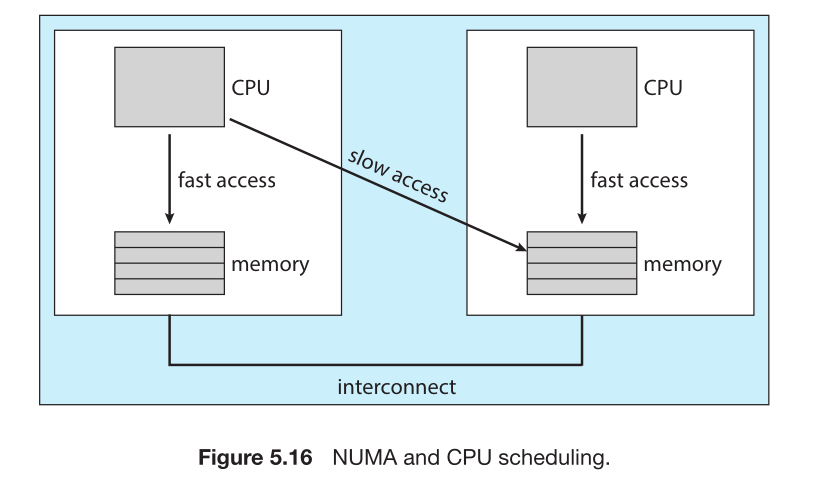

- **Go to Figure 5.16:** This figure shows a NUMA system where there are two physical processor chips, each with its own CPU and its own local, physical memory.
- While all CPUs share a single *address space* (they can all access all memory), access times are not uniform. A CPU can access its **local memory** very quickly, but accessing memory that is "local" to another CPU is much slower because it has to travel over a system interconnect.

This has a major scheduling implication: If a thread is scheduled on CPU 1 but the data it needs is in the memory local to CPU 2, it will suffer from slow memory access times.

Therefore, on a NUMA-aware system, the scheduler and memory manager work together. The goal is to:

1. Schedule a thread on a specific CPU.
2. Allocate the memory for that thread from the pool of memory that is *local* to that CPU.

This pairing of a thread with its "local" CPU and memory provides the fastest possible memory access.

#### **The Central Conflict: Load Balancing vs. Affinity/NUMA**

The text highlights a fundamental tension in multiprocessor scheduling:

- **The Goal of Processor Affinity & NUMA-Awareness:** Keep a thread on one processor to maximize cache warmth and minimize memory access latency.
- **The Goal of Load Balancing:** Move threads *away* from their current processor to evenly distribute work.

These two goals directly oppose each other. Load balancing, by moving threads, actively destroys the performance benefits gained from a warm cache and optimal NUMA memory placement.

This conflict is why scheduling algorithms for modern multicore and NUMA systems are extremely complex. They must intelligently balance the need for keeping all CPUs busy (load balancing) against the need for keeping individual thread performance high (by respecting affinity and NUMA locality). The Linux CFS scheduler, which we will explore later, is a prime example of an algorithm that deals with this complex trade-off.

### **5.5.5 Heterogeneous Multiprocessing**

#### **Moving Beyond Identical Cores**

Up until now, we've assumed that in a multiprocessor system, all CPUs or cores are identical (homogeneous). This means any thread can run on any core with the same expected performance, and the main scheduling concerns were load balancing and cache affinity.

**Heterogeneous Multiprocessing (HMP)** changes this assumption. In an HMP system, the cores are *not* all identical. They run the same instruction set (so they can execute the same programs), but they differ significantly in:

- **Clock Speed** (performance)
- **Power Consumption** (energy efficiency)
- **Power Management Capabilities** (e.g., the ability to be idled or put into low-power states)

**Important Distinction:** This is **not** the same as Asymmetric Multiprocessing (AMP) from Section 5.5.1. In AMP, only certain processors can run the kernel or handle I/O. In HMP, *any* task (system or user) can run on *any* core. The difference is that the cores themselves have different performance and power characteristics.

#### **The Goal: Intelligent Power and Performance Management**

The primary intention behind HMP is to manage power consumption intelligently, which is crucial for mobile and battery-powered devices. The scheduler's job becomes more complex: it must assign tasks to specific cores based not just on readiness, but on the task's performance demands and the core's power profile.

#### **The big.LITTLE Architecture**

A prominent example of HMP, used in ARM processors, is the **big.LITTLE** architecture. This design pairs two types of cores:

- **"big" Cores:** These are high-performance cores. They can execute tasks very quickly.
  - **Trade-off:** This high performance comes at the cost of high energy consumption. Because they use so much power, they should only be used for short, intensive bursts to avoid draining the battery and generating excess heat.
- **"LITTLE" Cores:** These are highly energy-efficient cores. They are slower than the "big" cores.
  - **Trade-off:** They sacrifice peak performance for very low power consumption, allowing them to run for long periods without significant battery drain.

#### **Scheduling Strategy in an HMP System**

The CPU scheduler in an HMP system uses a strategy that maps tasks to the most appropriate core type:

1. **Assigning to "LITTLE" Cores:** Tasks that do not require high performance but may run for a long time are assigned to the energy-efficient LITTLE cores. Examples include background synchronization, playing music, or monitoring sensors. This preserves battery life.
2. **Assigning to "big" Cores:** Tasks that require high processing power and are interactive are assigned to the high-performance big cores. Examples include launching an app, rendering a complex web page, or playing a game. These tasks get the performance they need for a responsive user experience.
3. **Power-Saving Mode:** The system can dynamically disable the energy-intensive "big" cores entirely. When the device is in a power-saving mode, the system can rely solely on the "LITTLE" cores to extend battery life as much as possible.

**Operating System Support:** Modern OSes like Windows 10 support HMP scheduling. They often provide interfaces that allow a thread to specify a scheduling policy that aligns with its power management needs, giving the scheduler a hint about where it should best be placed.

## **5.6 Real-Time CPU Scheduling**

#### **Introduction to Real-Time Systems**

Real-time operating systems have requirements that are fundamentally different from the general-purpose systems (like your laptop or phone) we've discussed so far. For a real-time system, **correctness depends not only on the *logical result* of the computation but also on the *time* at which the results are produced.**

Missing a timing deadline can lead to a system failure, the severity of which defines the two main categories of real-time systems.

#### **Soft Real-Time Systems**

- **Definition:** A soft real-time system **provides no strict guarantee** about when a critical real-time task will be scheduled and completed.
- **Guarantee:** The only guarantee offered is that critical real-time processes will be given **preference** over non-critical, ordinary processes. They will be scheduled first, whenever possible.
- **Consequence of Missing a Deadline:** In a soft real-time system, missing a deadline is undesirable and degrades the quality of service, but it is not considered a catastrophic failure of the entire system.
- **Example:** Streaming video or audio. If a frame is late, you might experience a glitch or a skip, but the video keeps playing. The system remains functional.

#### **Hard Real-Time Systems**

- **Definition:** A hard real-time system has **absolute and strict timing requirements**. A task *must* be serviced within its specified deadline.
- **The Critical Rule:** Service after the deadline has expired is equivalent to no service at all. In fact, a late result can often be worse than no result, as it may be incorrect or cause the system to take a wrong action.
- **Consequence of Missing a Deadline:** Missing a deadline is considered a complete and utter system failure.
- **Example:** The anti-lock braking system (ABS) in a car. If a sensor detects a wheel locking up, the control algorithm *must* compute and execute the corrective action (pulsing the brake) within a few milliseconds. If this computation misses its deadline, the wheel remains locked, and the car may skid, leading to an accident. The system has failed in its primary function.

This section will explore the specific scheduling algorithms and challenges involved in meeting these stringent timing demands for both soft and hard real-time systems.

### **5.6.1 Minimizing Latency**

#### **The Core Concept: Event Latency**

Real-time systems are fundamentally **event-driven**. They sit idle, waiting for specific events to occur. These events can be:

- **Software Events:** Such as a timer expiring.
- **Hardware Events:** Such as a sensor detecting an obstacle.

When an event occurs, the system must respond to it and perform the required service as quickly as possible. The time delay between the event occurring and it being serviced is called **Event Latency**.

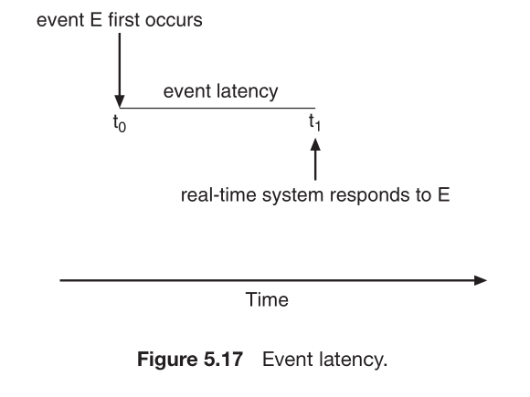

- **Go to Figure 5.17:** This figure illustrates event latency. At time `t0`, the event E first occurs. At time `t1`, the real-time system finally responds to it. The period between `t0` and `t1` is the event latency.

Different systems have vastly different latency requirements. An anti-lock brake system must respond within **3-5 milliseconds**, while an aircraft's radar system might tolerate a latency of **several seconds**.

#### **The Two Critical Types of Latency**

The total event latency is composed of two main parts that the operating system must minimize.

**1. Interrupt Latency**

- **Definition:** The period of time from when an interrupt signal arrives at the CPU to when the specific **Interrupt Service Routine (ISR)** that handles it actually begins executing.
- **What happens during this time?** The OS cannot instantly respond to the interrupt. It must:
  1. Finish executing the current CPU instruction.
  2. Determine the type of interrupt that occurred.
  3. Save the state of the current process (so it can be resumed later) before jumping to the ISR.
- The total time to perform these tasks is the interrupt latency.
- **Go to Figure 5.18:** This figure shows a task T running. An interrupt occurs, but the ISR does not start immediately. The period between the interrupt and the start of the ISR is the interrupt latency, which includes the time to determine the interrupt type and perform a context switch.

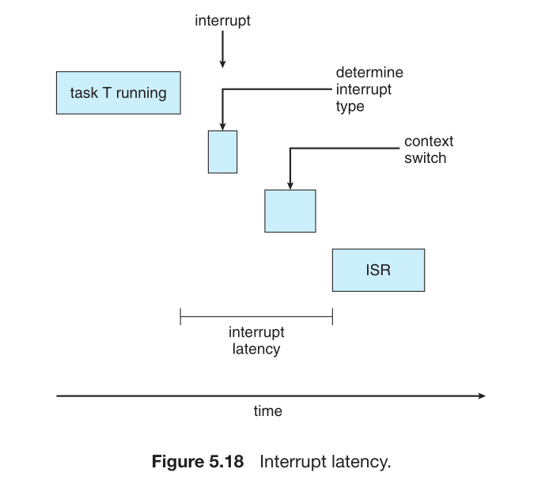

- **Minimization:** For real-time systems, especially **hard real-time systems**, it is not enough to just make this latency small on average; it must have a **known, strict upper bound (bounded)**. A key factor that increases interrupt latency is if the OS disables interrupts for too long while it is updating critical kernel data structures. Real-time OSes keep these periods extremely short.

**2. Dispatch Latency**

- **Definition:** The amount of time required for the scheduler's **dispatcher** to stop one process and start another one running.
- **The Goal:** To get the time-critical, high-priority process onto the CPU as fast as possible once it is ready. The most important technique for achieving low dispatch latency is using a **preemptive kernel**, which allows a higher-priority process to interrupt a lower-priority one even if it is executing a kernel call. In hard real-time systems, dispatch latency is often measured in microseconds.
- **Go to Figure 5.19:** This figure breaks down the **response interval** (the total time from event to response) and highlights the components of **dispatch latency** within it.

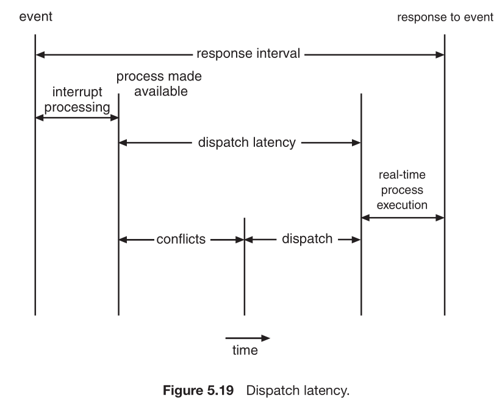

#### **The Components of Dispatch Latency: The Conflict Phase**

Dispatch latency is not a single action. Its most complex part is the **conflict phase**, which consists of two components:

1. **Preemption of any process running in the kernel:** The dispatcher must first preempt (stop) whatever process is currently running on the CPU, even if that process is executing a system call in the kernel.
2. **Release by low-priority processes of resources needed by a high-priority process:** This is a more serious issue. If a low-priority process holds a resource (like a lock on a shared data structure) that the high-priority real-time task needs, the high-priority task must **wait** for the low-priority task to release that resource. This situation, where a higher-priority task is blocked by a lower-priority one, is a major problem in real-time systems.

Once the conflict phase is resolved, the actual **dispatch phase** (switching the context to the new process) is relatively fast. The primary challenge is minimizing the delays caused by the conflict phase.

### **5.6.2 Priority-Based Scheduling**

#### **The Foundation of Real-Time Scheduling**

The most critical requirement for a real-time operating system is to respond immediately to a real-time process the moment it needs the CPU. To achieve this, the scheduler **must** be built on two pillars:

1. **Priority-Based Scheduling**
2. **Preemption**

This means each process is assigned a priority, with more important (real-time) tasks getting higher priorities. Furthermore, if a higher-priority process becomes ready to run, it will **immediately preempt** (kick off) whatever lower-priority process is currently using the CPU.

#### **Soft Real-Time in Practice**

As discussed in Section 5.3.4, preemptive, priority-based scheduling is the standard mechanism used. Major operating systems implement this for soft real-time support:

- **Windows:** Has 32 priority levels. Levels 16 to 31 are specifically **reserved for real-time processes**.
- **Solaris and Linux:** Use similar schemes, where real-time processes are assigned the highest possible scheduler priorities.

**Crucial Distinction:** It is vital to understand that providing a preemptive, priority-based scheduler **only guarantees soft real-time functionality**. It gives real-time tasks preference but makes **no absolute promise** that they will always meet their deadlines. For **hard real-time systems**, where missing a deadline is a system failure, we need more sophisticated schedulers that can make and keep such guarantees.

#### **Characterizing Processes for Hard Real-Time Scheduling**

To build a scheduler for hard real-time systems, we first need to define the processes more formally. These processes are typically **periodic**, meaning they require the CPU at constant, predictable intervals. Each periodic process is characterized by three parameters:

1. **Processing Time (`t`):** The fixed worst-case execution time the process needs on the CPU during each period.
2. **Deadline (`d`):** The time by which the process *must* finish its execution for that period.
3. **Period (`p`):** The fixed time interval between consecutive arrivals of the process.

The relationship between these parameters is: **0 ≤ t ≤ d ≤ p**

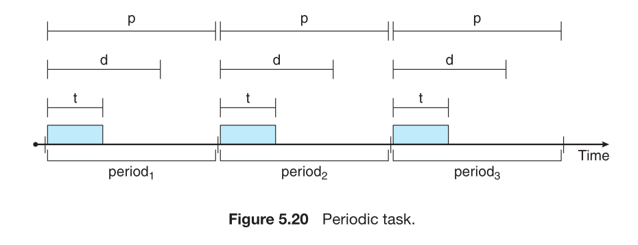

- **Go to Figure 5.20:** This figure illustrates a periodic task. You can see the task arriving and executing at regular intervals (period1, period2, period3). The processing time `t` is the shaded portion where it runs, and it always finishes within its deadline `d` for that period. The rate of the task (how often it occurs) is 1/`p`.

#### **The Admission Control Paradigm**

Hard real-time scheduling introduces a unique concept not found in general-purpose scheduling: **Admission Control**.

Here is how it works:

1. A process must **announce its real-time requirements** to the scheduler. It essentially says, "I am a periodic task with period `p`, deadline `d`, and required computation time `t`."
2. The scheduler then runs an **admission-control algorithm**. This algorithm performs a feasibility test.
3. The scheduler then makes a definitive decision:
   - **ADMIT:** If the scheduler can **guarantee** that the new task can be scheduled without causing itself or any existing task to miss a deadline, it admits the process and makes that guarantee.
   - **REJECT:** If the scheduler determines that it **cannot** make this guarantee, it rejects the process's request as **impossible to satisfy**. The task may not be run at all.

This "admit or reject" strategy is fundamental to hard real-time systems. It allows the system to know with certainty that all admitted tasks will meet their deadlines, which is the core requirement of a hard real-time environment.

### **5.6.3 Rate-Monotonic Scheduling**

#### **The Algorithm: Priority by Period**

Rate-Monotonic Scheduling (RMS) is a classic algorithm for scheduling periodic tasks in hard real-time systems. It operates as a **static priority preemptive** scheduler.

- **Static Priority:** A task's priority is fixed and assigned when it is created. It does not change during execution.
- **Preemptive:** A higher-priority task can always take the CPU away from a lower-priority task.

The core rule of RMS is simple: **Assign a priority inversely based on the task's period.**

- **Shorter Period = Higher Priority**
- **Longer Period = Lower Priority**

**Why this rule?** The rationale is that a task with a short period needs the CPU more frequently. To ensure it can meet all its frequent deadlines, it is given a higher priority. RMS also makes an important assumption: the processing time (CPU burst) of every periodic task is the same each time it runs.

#### **An Example: Scheduling Two Tasks**

Let's define two periodic processes:

- **Process P1:** Period `p1 = 50`, Processing Time `t1 = 20`
- **Process P2:** Period `p2 = 100`, Processing Time `t2 = 35`

The deadline for each task is the start of its next period. First, we check the total CPU load:

- CPU utilization of P1 = `t1/p1` = 20/50 = **0.40** (40%)
- CPU utilization of P2 = `t2/p2` = 35/100 = **0.35** (35%)
- **Total CPU Utilization = 75%**

Since the total utilization is less than 100%, it seems theoretically possible to schedule both tasks.

#### **Scenario 1: Incorrect Priority Assignment**

Let's see what happens if we incorrectly assign **P2 a higher priority than P1**.

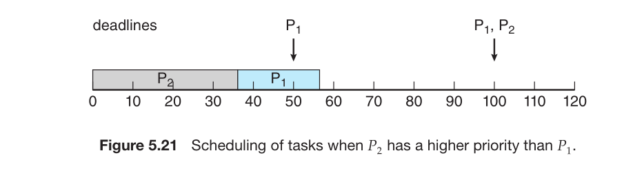

- **Go to Figure 5.21:** This figure shows the schedule under this policy.
  1. **Time 0-35:** P2 (higher priority) runs first and completes its full 35 ms burst.
  2. **Time 35-55:** P1 (lower priority) finally starts. It runs for 20 ms, finishing at time 55.
  3. **The Problem:** P1's first deadline was at time 50 (the start of its next period). Since it finished at time 55, **it has missed its deadline**. This shows that even with low total CPU usage, a wrong scheduling policy can cause failures.

#### **Scenario 2: Rate-Monotonic Scheduling**

Now, let's apply the RMS rule. Since P1 has a shorter period (50 vs. 100), it is assigned a **higher priority than P2**.

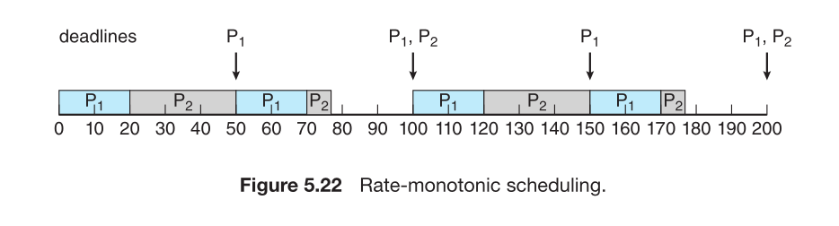

- **Go to Figure 5.22:** This figure shows the correct RMS schedule.
  1. **Time 0-20:** P1 (higher priority) runs first and completes its 20 ms burst well before its deadline of 50.
  2. **Time 20-50:** P2 (lower priority) begins running. It runs for 30 ms.
  3. **Time 50:** This is a critical moment. P1 becomes ready again at the start of its new period. Because P1 has a higher priority, it **preempts** P2, even though P2 has only used 30 of its 35 ms of CPU time.
  4. **Time 50-70:** P1 runs its second CPU burst, finishing at time 70.
  5. **Time 70-75:** P2 resumes and completes its remaining 5 ms of computation.
  6. **Checking Deadlines:**
     - P1 finished its first burst at time 20 (deadline was 50) and its second burst at time 70 (deadline was 100). **All deadlines met.**
     - P2 finished its first burst at time 75 (deadline was 100). **Deadline met.**

#### **The Limits of Optimality**

The previous example showed Rate-Monotonic Scheduling (RMS) working correctly. It is considered **optimal among all static-priority schedulers**. This means that if a set of periodic tasks *cannot* be scheduled using RMS (where priority is the inverse of the period), then that set of tasks **cannot** be scheduled using *any* other static-priority assignment policy.

However, "optimal" does not mean "able to schedule everything." RMS has fundamental limits.

#### **An Example Where RMS Fails**

Let's examine a set of two processes that RMS cannot successfully schedule:

- **Process P1:** Period `p1 = 50`, Processing Time `t1 = 25`
- **Process P2:** Period `p2 = 80`, Processing Time `t2 = 35`

Following the RMS rule, P1 has a shorter period and thus gets a **higher priority** than P2.

First, check the CPU utilization:

- P1 utilization = 25/50 = **0.50** (50%)
- P2 utilization = 35/80 = **0.4375** (43.75%)
- **Total CPU Utilization = 0.9375 (93.75%)**

Since utilization is less than 100%, it seems possible. However, let's see the actual schedule.

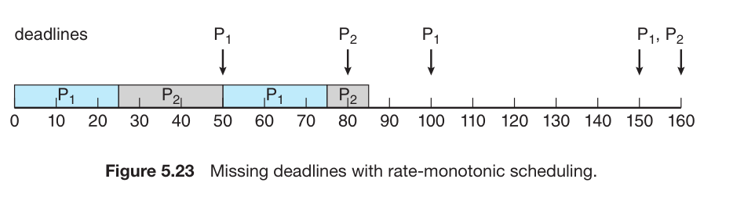

- **Go to Figure 5.23:** This figure shows the timeline where deadlines are missed.
  1. **Time 0-25:** P1 (high priority) runs and completes its full 25 ms burst.
  2. **Time 25-50:** P2 (low priority) starts and runs for 25 ms. It has used 25 of its 35 ms needed.
  3. **Time 50:** P1 becomes ready again at the start of its next period. It preempts P2.
  4. **Time 50-75:** P1 runs its next full 25 ms burst.
  5. **Time 75-85:** P2 resumes and finishes its remaining 10 ms.
  6. **The Problem:** P2's first deadline was at time 80 (the start of its next period). However, P2 does not finish its required computation until **time 85**. Therefore, **P2 has missed its deadline**.

This demonstrates a critical point: even with a total CPU utilization less than 100% (here, 93.75%), a schedule that meets all deadlines may not exist with a static-priority scheme.

#### **The CPU Utilization Bound**

The previous example leads to the most important limitation of RMS: **there is a mathematical upper bound on the total CPU utilization for which RMS can guarantee all deadlines.**

This worst-case utilization bound for scheduling N processes is: **N(2^(1/N) - 1)**

Let's calculate this bound for different values of N:

- **For N = 1 process:** 1 * (2^(1/1) - 1) = 1 * (2 - 1) = **1.00 (100%)**
- **For N = 2 processes:** 2 * (2^(1/2) - 1) = 2 * (√2 - 1) ≈ 2 * (1.414 - 1) = **~0.828 (82.8%)**
- **For N = 3 processes:** 3 * (2^(1/3) - 1) ≈ 3 * (1.26 - 1) = **~0.78 (78%)**
- **As N approaches infinity:** The bound approaches **ln(2) ≈ 0.693 (69.3%)**

**What this means in practice:** If the total CPU utilization of your set of tasks is below this bound, RMS is **guaranteed** to be able to schedule them successfully.

- In Figure 5.21/5.22, the utilization was 75%, which is **below** the 82.8% bound for two tasks. RMS worked.
- In Figure 5.23, the utilization was ~94%, which is **above** the 82.8% bound for two tasks. RMS failed, and any other static-priority scheduler would also fail.

This utilization bound is why admission control in hard real-time systems is not just about checking for 100% utilization; it must check against this stricter, lower bound to provide a guarantee.

### **5.6.4 Earliest-Deadline-First Scheduling**

#### **The Algorithm: Dynamic Priority by Deadline**

Earliest-Deadline-First (EDF) scheduling is a dynamic priority algorithm used for hard real-time systems. Its core principle is:

- **The earlier the deadline, the higher the priority.**
- **The later the deadline, the lower the priority.**

This is a fundamental shift from Rate-Monotonic Scheduling (RMS).

- In **RMS**, priorities are **static** (fixed based on the period at the start).
- In **EDF**, priorities are **dynamic** and can change whenever a new process becomes runnable.

To make this work, a process must **announce its deadline requirement to the scheduler** as soon as it becomes ready to run. The scheduler then adjusts the priorities of all runnable tasks to reflect the new deadlines.

#### **EDF in Action: Solving the RMS Problem**

Let's apply EDF to the same problem that caused RMS to fail in Figure 5.23. The processes are:

- **Process P1:** Period `p1 = 50`, Processing Time `t1 = 25` (Deadlines at 50, 100, 150...)
- **Process P2:** Period `p2 = 80`, Processing Time `t2 = 35` (Deadlines at 80, 160...)

The total CPU utilization is still 93.75%.

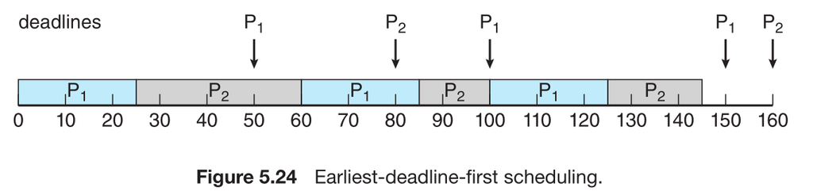

As the timeline shows, EDF successfully navigates the high-utilization scenario where RMS failed.

#### **Advantages and Theoretical Optimality of EDF**

EDF has several significant advantages over RMS:

1. **Greater Flexibility:** It does not require processes to be periodic, nor does it require that a process uses the same amount of CPU time in every burst. The only requirement is that a process announces its deadline whenever it becomes runnable.
2. **Theoretical Optimality:** EDF is **theoretically optimal** among all scheduling algorithms on a single processor. This means that **if a set of tasks is schedulable (i.e., it is possible to meet all deadlines), then EDF is capable of producing a valid schedule.**
3. **High Utilization Bound:** Because it is optimal, EDF can theoretically achieve **100% CPU utilization** while still meeting all deadlines. The utilization-based test for EDF is simple: if the total CPU utilization of all tasks is **≤ 100%**, then the task set is schedulable using EDF.

**Practical Limitation:** In practice, 100% utilization is impossible to achieve because of the overhead costs of context switching between processes and handling interrupts. However, the utilization bound for EDF is still significantly higher than the ~69% bound for RMS as the number of tasks grows large, making EDF a much more powerful algorithm for hard real-time systems.

### **5.6.5 Proportional Share Scheduling**

#### **The Core Concept: Dividing Time with Shares**

Proportional Share Scheduling is a different approach to real-time scheduling. Instead of being driven by deadlines (like EDF) or fixed periods (like RMS), it focuses on guaranteeing a specific fraction or percentage of the CPU time to each process or application.

The system works by defining a total number of **T shares** (or tickets) that represent the entire processing resource of the CPU. Each application is then allocated a certain number of these shares, **N**. This allocation guarantees that the application will receive at least **N/T** of the total processor time.

#### **A Detailed Example**

Let's walk through the example from the text:

- The total number of shares in the system is **T = 100**.
- We have three processes with the following share allocations:
  - Process A: **50 shares**
  - Process B: **15 shares**
  - Process C: **20 shares**

From these allocations, we can calculate the guaranteed proportion of CPU time for each process:

- Process A: 50 / 100 = **50%** of the CPU time.
- Process B: 15 / 100 = **15%** of the CPU time.
- Process C: 20 / 100 = **20%** of the CPU time.

The sum of the allocated shares is 50 + 15 + 20 = **85 shares**. This means 15 shares are still unallocated and represent free, unreserved CPU capacity.

#### **The Role of Admission Control**

A Proportional Share scheduler **must** be used with a strict **admission-control policy** to work correctly. The guarantee that a process gets its N/T of the CPU time is only possible if the system does not oversell the total available shares.

The job of the admission controller is to admit a new process only if there are enough free shares to satisfy its request.

- **In our example:** A new Process D requests **30 shares**.
- **Admission Control Check:** The system has only 100 - 85 = **15 free shares** available.
- **Decision:** Since 30 > 15, the admission controller **denies** the request from Process D. It is not allowed to run under the proportional share scheduler because granting its request would make it impossible to honor the existing guarantees given to Processes A, B, and C.

This "admit or reject" policy is essential for the scheduler to provide mathematically sound performance guarantees, similar to the admission control used in hard deadline scheduling.

### **5.6.6 POSIX Real-Time Scheduling**

#### **Introduction to the POSIX.1b Standard**

To allow for real-time computing in a standardized way, the POSIX standard includes an extension known as **POSIX.1b**. This defines a set of Application Programming Interfaces (APIs) that allow a programmer to control how threads are scheduled. We will focus on the APIs related to scheduling classes.

#### **The POSIX Real-Time Scheduling Classes**

POSIX defines two primary scheduling classes designed for real-time threads:

1. **`SCHED_FIFO` (First-In, First-Out)**
   - This policy schedules threads based on a **first-come, first-served** policy within a given priority level, using a FIFO queue as described in Section 5.3.1.
   - **Crucial Detail: There is no time slicing (round-robin) among threads of the same priority.**
   - **Consequence:** The highest-priority real-time thread at the front of its queue will be granted the CPU and will run until it:
     - Voluntarily terminates.
     - Blocks (e.g., for I/O or on a lock).
     - Is preempted by a higher-priority thread that becomes ready.
2. **`SCHED_RR` (Round Robin)**
   - This policy is similar to `SCHED_FIFO` in that it uses priority-based queues.
   - **Key Difference:** It **does provide time slicing** among threads of **equal** priority.
   - **Consequence:** If multiple threads with the same priority are ready, they are granted the CPU in turn, each for a specific time quantum. This prevents a single compute-bound thread from monopolizing the CPU at the expense of other same-priority threads.
3. **`SCHED_OTHER`**
   - This is an additional scheduling class, but its implementation is **undefined and system-specific** by the POSIX standard.
   - It represents the default, non-real-time scheduling policy (in Linux, this is the standard CFS scheduler). Its behavior can vary across different operating systems.

#### **The POSIX API for Scheduling Policy**

POSIX specifies functions to get and set the scheduling policy for a thread. These functions manipulate the thread's attribute object, which is used when creating a thread.

**The Functions:**

- **`pthread_attr_getschedpolicy(pthread_attr_t *attr, int *policy)`**
  - **Purpose:** This function **gets** the current scheduling policy from a thread attribute object.
  - **Parameters:**
    - `*attr`: A pointer to the thread attribute structure.
    - `*policy`: A pointer to an integer where the current policy (`SCHED_FIFO`, `SCHED_RR`, etc.) will be stored.
  - **Return Value:** Returns a nonzero value if an error occurs.
- **`pthread_attr_setschedpolicy(pthread_attr_t *attr, int policy)`**
  - **Purpose:** This function **sets** the scheduling policy in a thread attribute object.
  - **Parameters:**
    - `*attr`: A pointer to the thread attribute structure.
    - `policy`: An integer value specifying the desired policy (`SCHED_FIFO`, `SCHED_RR`, etc.).
  - **Return Value:** Returns a nonzero value if an error occurs.

**How they are used:** The text refers to **Figure 5.25**, which shows a sample program. The typical flow is:

1. The program first uses `pthread_attr_getschedpolicy()` to check the current scheduling policy.
2. It then uses `pthread_attr_setschedpolicy()` to change the policy to `SCHED_FIFO` (or another real-time policy).
3. When a thread is created using this modified attribute object, it will run under the newly set scheduling policy.

## **5.7 Operating-System Examples**

### **5.7.1 Example: Linux Scheduling**

#### **A History of Linux Schedulers**

The Linux scheduler has evolved significantly over time to address changing hardware and workload demands.

**1. The Pre-2.5 Era: Traditional UNIX Scheduler**

- Early versions of Linux used a variation of the classic UNIX scheduling algorithm.
- **Major Flaws:**
  - It was not designed with **Symmetric Multi-Processing (SMP)** in mind. It did not handle multiple processors effectively.
  - Its performance degraded badly when the system had a large number of runnable processes.

**2. The O(1) Scheduler (Kernel Version 2.5 and 2.6)**

- This was a major overhaul to fix the problems of the old scheduler. Its name, "O(1)", describes its key feature: its operations (such as selecting a task to run) took **constant time**, regardless of how many tasks were in the system. This made it very efficient on large systems.
- **Key Features it Introduced:**
  - **SMP Support:** It properly supported multiple processors, including:
    - **Processor Affinity:** To keep tasks on the same CPU and benefit from warm caches.
    - **Load Balancing:** To distribute work evenly across all CPUs.
- **The Problem:** In practice, while the O(1) scheduler was excellent for server workloads and SMP performance, it often resulted in **poor response times for interactive processes** (like those on a desktop), leading to a less responsive user interface.

**3. The Completely Fair Scheduler (CFS) (Kernel Version 2.6.23 and later)**

- Due to the interactive performance issues of the O(1) scheduler, it was replaced by the **Completely Fair Scheduler (CFS)**, which became the default scheduler starting with kernel release 2.6.23 and remains the default in modern Linux kernels.
- CFS was designed to provide superior fairness and responsiveness, especially for interactive tasks, while still performing well on SMP systems.

#### **POSIX Real-Time Scheduling API Code Example**

- **Go to Figure 5.25:** This C program demonstrates the use of the POSIX real-time scheduling API we discussed in Section 5.6.6.

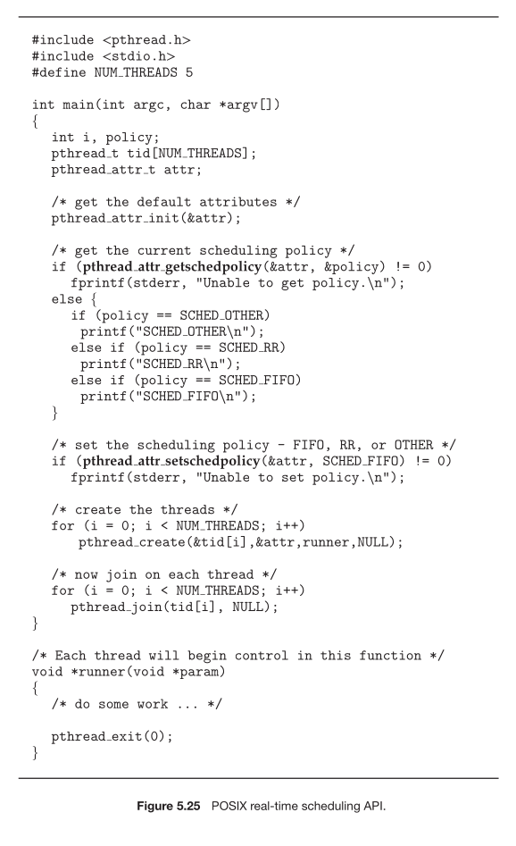

**What the code does, step-by-step:**

1. **Initialization:** It gets the default thread attributes using `pthread_attr_init()`.
2. **Get Policy:** It uses `pthread_attr_getschedpolicy()` to retrieve the current scheduling policy (e.g., `SCHED_OTHER`, `SCHED_RR`, `SCHED_FIFO`) and prints it out.
3. **Set Policy:** It uses `pthread_attr_setschedpolicy()` to change the scheduling policy for the new threads to `SCHED_FIFO`.
4. **Create Threads:** It creates five threads using `pthread_create()`. These new threads will inherit the `SCHED_FIFO` policy from the attribute object `attr`.
5. **Wait for Threads:** The main thread uses `pthread_join()` to wait for all five threads to finish their execution.
6. **Thread Function:** Each of the five threads begins executing in the `runner()` function, where they would perform their work.

#### **The Scheduling Class Framework**

Modern Linux scheduling is built on a modular framework of **scheduling classes**. Each class represents a different scheduling algorithm and is assigned a specific priority level.

- This design allows the kernel to use different scheduling algorithms for different types of tasks. For example, the needs of a Linux server differ from those of a mobile device, and this framework can accommodate that.
- The scheduler decides which task to run next with a simple rule: it looks at the **highest-priority scheduling class** that has runnable tasks and then selects the highest-priority task *within* that class.
- Standard kernels implement two main classes:
  1. The default class, which uses the **Completely Fair Scheduler (CFS)** algorithm.
  2. A real-time scheduling class.
- The framework is extensible, allowing new scheduling classes to be added.

#### **The Completely Fair Scheduler (CFS) Algorithm**

The CFS scheduler's goal is to be "fair," giving each task a fair share of the CPU. It does this in a unique way.

**1. Proportion-Based Scheduling and Nice Values**

- Instead of assigning fixed time slices, CFS assigns each task a **proportion** of the CPU processing time.
- This proportion is determined by the task's **nice value**. Nice values range from **-20 to +19**.
  - A **lower** nice value means a **higher** relative priority.
  - The default nice value is 0.
  - *Context: The term "nice" comes from the idea that a task that increases its nice value (e.g., from 0 to +10) is being "nice" to other tasks by lowering its own priority.*
- CFS uses a value called **targeted latency**, which is the time interval during which every runnable task should get to run at least once. The CPU time proportion for each task is calculated from this targeted latency. This latency can increase if there are many active tasks to maintain efficiency.

**2. The Core Mechanism: Virtual Run Time (vruntime)**

- CFS does not directly use nice values to pick the next task. Instead, it maintains a key metric for each task called the **virtual run time (vruntime)**.
- `vruntime` measures how long a task *has run*, but it is weighted by the task's priority.
  - For a task with **default priority (nice 0)**, `vruntime` increases at the same rate as real, physical time.
  - For a **higher-priority task (lower nice value, e.g., -10)**, `vruntime` increases **more slowly** than real time. This makes its `vruntime` value accumulate more slowly, so it gets to run more often.
  - For a **lower-priority task (higher nice value, e.g., +10)**, `vruntime` increases **more quickly** than real time. This makes its `vruntime` accumulate faster, so it gets to run less often.
- **The Scheduling Decision is Simple:** The scheduler always picks the runnable task with the **smallest `vruntime`** value. This task is the "most deserving" of CPU time. Preemption also works this way: if a sleeping task wakes up and has a smaller `vruntime` than the currently running task, it will preempt it.

**3. CFS in Action: I/O-bound vs. CPU-bound** Consider an I/O-bound task (like a text editor) and a CPU-bound task (like a video encoder) with the same nice value.

- The **I/O-bound task** runs in short bursts and then blocks for I/O. While it's blocked, its `vruntime` doesn't increase.
- The **CPU-bound task** runs for long periods, continuously increasing its `vruntime`.
- **Result:** After the I/O-bound task finishes waiting, it will have a much **lower `vruntime`** than the CPU-bound task. CFS will then immediately schedule the I/O-bound task, making the system feel responsive and interactive. This automatically gives I/O-bound tasks a priority boost without needing complex heuristics.

#### **Real-Time Scheduling in Linux**

Linux implements real-time scheduling according to the POSIX standard (`SCHED_FIFO` and `SCHED_RR`), as described in Section 5.6.6.

- Real-time tasks always have higher priority than normal CFS tasks.
- Linux uses two separate, unified priority ranges:

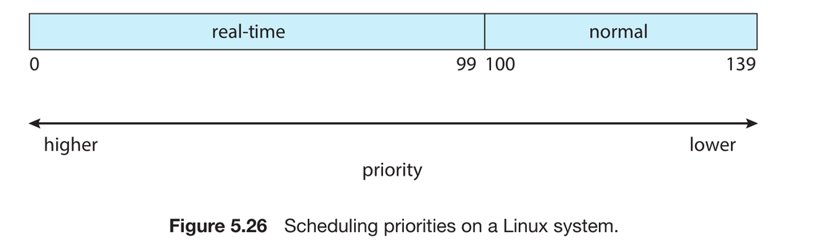

- **Go to Figure 5.26:** This figure illustrates the Linux priority scheme.
  - **Real-Time Priorities:** Range from **0 (highest) to 99**.
  - **Normal Priorities:** Range from **100 to 139 (lowest)**.
- The nice values for normal tasks (-20 to +19) map directly onto the priority range 100 to 139. A nice value of -20 equals priority 100, and a nice value of +19 equals priority 139. This creates a single, global priority scale where a lower number always means a higher priority.

#### **CFS Performance: The Red-Black Tree**

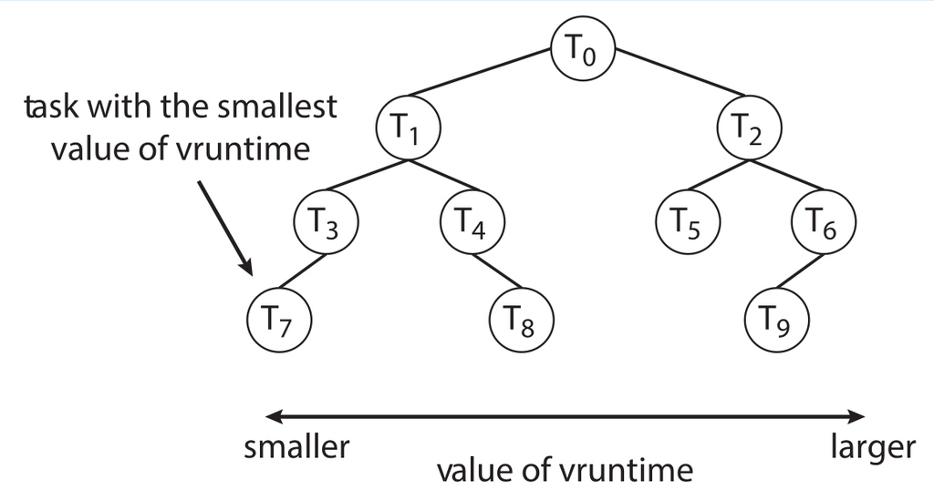

##### **The Data Structure for Efficiency**

The Linux CFS scheduler needs a very efficient way to manage its list of runnable tasks and to quickly identify the one with the smallest `vruntime`. Instead of using a standard linear queue, it uses a sophisticated data structure called a **red-black tree**.

**What is a Red-Black Tree?**

- It is a **self-balancing binary search tree**.
- "Binary search tree" means each node has at most two children, and nodes are organized such that for any node, all keys in its left subtree are less than its key, and all keys in its right subtree are greater.
- "Self-balancing" means the tree automatically reorganizes itself during insertions and deletions to prevent it from becoming a long, inefficient chain. This guarantees that operations remain efficient.

##### **How CFS Uses the Red-Black Tree**

In the CFS scheduler:

- **Each node in the tree represents a runnable task.**
- The **key** used to organize the tree is the task's **`vruntime`** value.

##### **How Operations Work**

1. **Adding a Task:** When a task becomes runnable (e.g., it's newly created or unblocks from I/O), it is inserted into the tree based on its `vruntime`. The tree rebalances itself if needed. This is an **O(log N)** operation.
2. **Removing a Task:** When a task stops being runnable (it blocks, terminates, or is moved to another CPU), it is removed from the tree, which then rebalances. This is also an **O(log N)** operation.
3. **Selecting the Next Task:** This is the most frequent and critical operation. In theory, finding the leftmost node in a balanced tree of N nodes is an **O(log N)** operation. However, CFS implements a crucial performance optimization: it **caches a pointer to the leftmost node** in a variable called `rb_leftmost`.
   - **This means that selecting the next task to run does not require searching the tree.**
   - The scheduler simply dereferences the `rb_leftmost` pointer, which is an **O(1) - constant time** operation.
   - The cached value is updated whenever the tree is modified (during insertions and deletions).

This combination of the red-black tree for efficient management of a dynamic task list and the `rb_leftmost` cache for instant selection of the next task is what makes the CFS scheduler both scalable (it works well with a huge number of tasks) and efficient (it makes scheduling decisions very quickly).

#### **CFS Load Balancing**

The CFS scheduler supports **load balancing** across multiple processors, but it uses a sophisticated approach.

- **Defining "Load":** In CFS, the load of a thread is not just the number of threads in a queue. It is a calculated metric that combines:
  1. The thread's **priority**.
  2. Its **average rate of CPU utilization**.
- **Implication of this Definition:** A high-priority thread that is mostly I/O-bound (and thus uses little CPU) will have a **low load**, similar to a low-priority thread. This gives a more accurate picture of CPU demand than simply counting threads.
- **Queue Load:** The total load of a CPU's run queue is the sum of the loads of all threads in that queue. The goal of load balancing is to make the load on all queues approximately equal.

#### **The Challenge: The Cost of Migration**

As discussed in Section 5.5.4, blindly moving threads between processors to balance load can be counterproductive because it can cause:

- **Cache Misses:** The new CPU's cache is "cold" for the migrated thread.
- **NUMA Penalties:** On NUMA systems, a thread may be moved to a CPU that is farther from its memory, leading to slower memory access times.

#### **The Solution: Scheduling Domains**

To address this, Linux CFS uses a hierarchical model of **scheduling domains**. A scheduling domain is a set of CPU cores that can be balanced against each other. The cores are grouped based on how they share hardware resources.

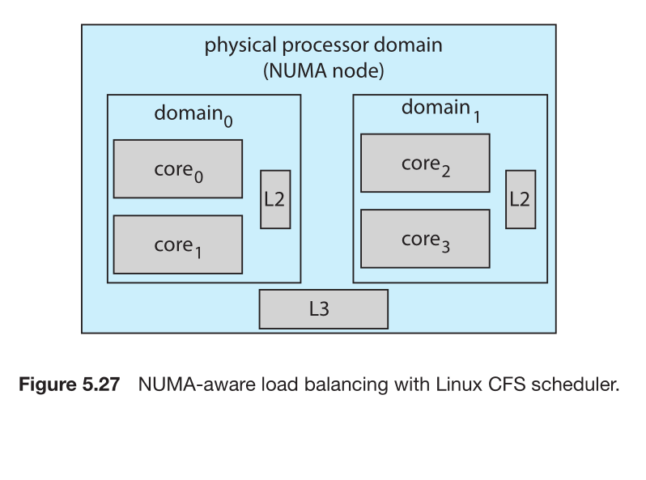

- **Go to Figure 5.27:** This figure illustrates the hierarchical scheduling domains.
  - At the lowest level, each core has its own L1 cache.
  - **Domain0 and Domain1:** Cores that share an L2 cache are grouped into a domain (e.g., core0 & core1 in domain0; core2 & core3 in domain1). Migrating a thread within this domain is relatively cheap because the cores share the L2 cache.
  - **Processor-Level Domain (NUMA Node):** The next level up combines domains that share an L3 cache. This is often a NUMA node. Migrating a thread within this node is more expensive than within an L2 domain, but cheaper than moving between NUMA nodes.
  - **System-Level Domain:** On a larger NUMA system, an even higher level would combine separate processor-level NUMA nodes. Migration at this level is the most expensive.

#### **The Load Balancing Strategy**

CFS uses a strategic, hierarchical approach to load balancing:

1. **Balance at the Lowest Level First:** The scheduler first attempts to balance load within the smallest, most tightly-coupled domain (e.g., within `domain0` itself). This minimizes migration cost by keeping threads on cores that share a cache.
2. **Progress Up the Hierarchy:** If a significant imbalance persists, balancing then occurs at the next level (e.g., between `domain0` and `domain1`).
3. **Reluctance for NUMA Migration:** CFS is very **reluctant to migrate threads between separate NUMA nodes**. It will only do this under **severe load imbalances** because the performance penalty of remote memory access is so high.
4. **General Rule:** If the overall system is busy, CFS will typically not load-balance beyond the domain local to each core to avoid the memory latency penalties of NUMA systems. It prefers a slight load imbalance over a significant increase in memory access time.

This NUMA-aware strategy allows CFS to balance load effectively while intelligently managing the trade-off between CPU utilization and memory access latency.

### **5.7.2 Example: Windows Scheduling**

#### **The Core Algorithm**

The Windows operating system uses a **priority-based, preemptive** scheduling algorithm. The part of the Windows kernel responsible for this is called the **dispatcher**.

- **Fundamental Rule:** The dispatcher ensures that the **highest-priority runnable thread will always be the one that is running**.
- A thread that is selected to run will continue until one of four things happens:
  1. It is **preempted** by a higher-priority thread.
  2. It **terminates**.
  3. Its **time quantum** (time slice) expires.
  4. It performs a **blocking** system call (e.g., for I/O).

This design guarantees that high-priority threads (especially real-time ones) get immediate access to the CPU when they need it.

#### **The 32-Level Priority Scheme**

The dispatcher manages threads using a **32-level priority scheme** (from 0 to 31). These priorities are divided into two main classes:

1. **Variable Class (Priorities 1-15):** This class contains most user and application threads. Their priorities can be dynamically adjusted by the OS.
2. **Real-Time Class (Priorities 16-31):** This class contains high-priority threads. Their priorities are static and are not adjusted by the OS.
3. **Priority 0:** Reserved for a special thread used for memory management operations.

**How the dispatcher selects a thread:**

- It maintains a separate queue for each of the 32 priority levels.
- It checks these queues in order from **highest priority (31) to lowest (0)**.
- It runs the first ready thread it finds.
- If no threads are ready, it runs a special **idle thread**.

#### **Process Priority Classes and Thread Relative Priorities**

There is a mapping between the numeric kernel priorities (1-31) and what a programmer specifies using the Windows API.

**A. Process Priority Classes** A process belongs to one of six priority classes, which sets the general importance of all its threads:

- `IDLE_PRIORITY_CLASS`
- `BELOW_NORMAL_PRIORITY_CLASS`
- `NORMAL_PRIORITY_CLASS` (This is the **typical default**)
- `ABOVE_NORMAL_PRIORITY_CLASS`
- `HIGH_PRIORITY_CLASS`
- `REALTIME_PRIORITY_CLASS`

A process's priority class can be set at creation or changed using the `SetPriorityClass()` API function.

**B. Thread Relative Priorities** Within a given priority class, an individual thread can have a relative priority that modifies its base importance. The relative priorities are:

- `IDLE`
- `LOWEST`
- `BELOW_NORMAL`
- `NORMAL`
- `ABOVE_NORMAL`
- `HIGHEST`
- `TIME_CRITICAL`

#### **Mapping to a Numeric Priority**

The final numeric priority (from 1 to 31) of a thread is determined by combining its **Process Priority Class** and its **Thread Relative Priority**.

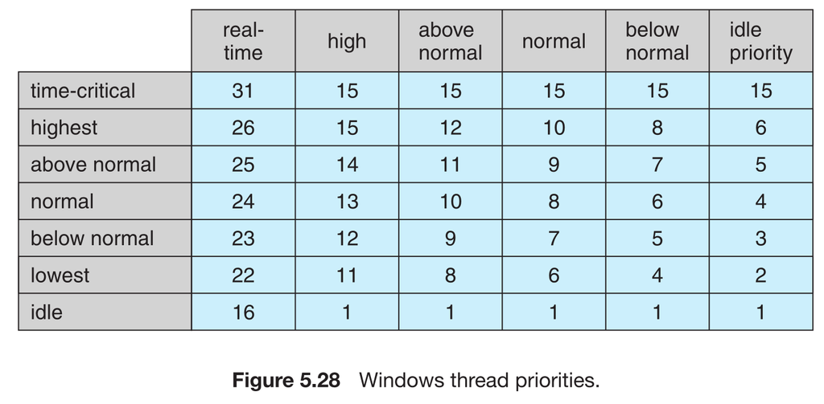

- **Go to Figure 5.28:** This table shows the complete mapping. To find a thread's numeric priority:
  1. Find its **Priority Class** in the top row.
  2. Find its **Relative Priority** in the left column.
  3. The cell where the row and column intersect is the thread's **numeric priority**.
  - *Example:* A thread in the `ABOVE_NORMAL_PRIORITY_CLASS` with a `NORMAL` relative priority has a numeric priority of **10**.

#### **Base Priority**

Each thread has a **base priority**, which is the default priority value within its class.

- By default, the base priority is the value corresponding to the `NORMAL` relative priority for that class.
- The base priorities for the default `NORMAL` relative priority are:
  - `REALTIME_PRIORITY_CLASS` — 24
  - `HIGH_PRIORITY_CLASS` — 13
  - `ABOVE_NORMAL_PRIORITY_CLASS` — 10
  - `NORMAL_PRIORITY_CLASS` — 8
  - `BELOW_NORMAL_PRIORITY_CLASS` — 6
  - `IDLE_PRIORITY_CLASS` — 4

A thread typically starts with the base priority of its process, but this can be changed using the `SetThreadPriority()` API function.

#### **Dynamic Priority Adjustment for Variable-Class Threads**

For threads in the **variable-priority class (1-15)**, Windows dynamically adjusts their priority to optimize system behavior and user experience. These adjustments are made based on how the thread uses the CPU.

**1. Priority Lowering (For CPU-bound Threads)**

- **When it happens:** When a thread **uses up its entire time quantum** (time slice) and is interrupted.
- **The action:** The thread's priority is **lowered**.
- **The Limit:** The priority is **never lowered below the thread's base priority**.
- **The Goal:** This penalizes **compute-bound threads** that try to monopolize the CPU. By lowering their priority, they yield the CPU to other, potentially more interactive, threads.

**2. Priority Boosting (For I/O-bound and Interactive Threads)**

- **When it happens:** When a thread is **released from a wait operation** (e.g., after finishing an I/O request like a keypress or disk read).
- **The action:** The dispatcher **boosts (increases)** the thread's priority.
- **The Amount:** The boost is **not uniform**. It depends on what the thread was waiting for.
  - A thread waiting for a **keyboard or mouse event** gets a **large priority increase**. This is because such events are directly tied to user interactivity.
  - A thread waiting for a **disk operation** gets a **moderate increase**.
- **The Goal:**
  - To give **excellent response times to interactive threads**. When a user clicks, the waiting thread gets a high priority and runs immediately.
  - To allow **I/O-bound threads** to quickly issue their next I/O request, which helps keep I/O devices busy.
  - This strategy effectively allows I/O-bound and interactive threads to maintain high priority, while CPU-bound threads sink to lower priorities, using only the spare CPU cycles.

This general strategy of lowering priority on time-quantum expiration and boosting it after I/O waits is common and is also used by other operating systems, including UNIX variants.

#### **Special Foreground Process Boost**

Windows provides an additional performance optimization for the process the user is directly interacting with.

- **The Scenario:** A user is running an interactive program (like a word processor or a game) in a window.
- **The Distinction:** Windows identifies the **foreground process** (the process in the currently selected window) separately from **background processes**.
- **The Rule:** When a process in the `NORMAL_PRIORITY_CLASS` moves into the foreground, Windows does not change its priority, but it **increases its scheduling quantum**.
- **The Quantum Increase:** The factor is typically **3**. This means the foreground process gets **three times longer** to run before a time-sharing preemption occurs.
- **The Goal:** This longer time quantum reduces the overhead of context switches for the active application, giving it a larger, more contiguous chunk of CPU time. This results in smoother performance and better responsiveness for the application the user is actively using.

#### **Advanced Windows Scheduling Features**

##### **User-Mode Scheduling (UMS)**

Introduced in Windows 7, **User-Mode Scheduling (UMS)** is a powerful feature that allows applications to create and manage their own threads entirely in **user mode**, without requiring intervention from the Windows kernel scheduler for every context switch.

- **Benefit:** For applications that create a massive number of threads, this is vastly more efficient. The overhead of a system call for every scheduling decision is eliminated.
- **Comparison to Fibers:** Earlier versions of Windows had a similar concept called **fibers**, where multiple user-mode threads were mapped to a single kernel thread. However, fibers had a major limitation: they all had to share a single **Thread Environment Block (TEB)**, which is a kernel data structure. If one fiber made a Windows API call that modified the TEB, it would corrupt the state for all other fibers on that kernel thread.
- **UMS Advantage:** UMS overcomes this by providing **each user-mode thread with its own dedicated thread context**, including a separate TEB, allowing them to safely make Windows API calls.
- **Intended Use:** UMS is not meant to be used directly by most programmers. Writing a correct and efficient user-mode scheduler is very complex. Instead, UMS is a low-level mechanism used by **programming frameworks and libraries**. A prime example is Microsoft's **Concurrency Runtime (ConcRT)**, a C++ framework for task-based parallelism. ConcRT provides a user-mode scheduler that breaks programs into tasks and schedules them efficiently across CPU cores.

##### **Multiprocessor and SMT Scheduling**

Windows fully supports scheduling on multiprocessor systems, incorporating the concepts from Section 5.5, such as **processor affinity**.

**1. Logical Processors and SMT Sets**

- On systems with Simultaneous Multithreading (SMT), like Intel's Hyper-Threading, each physical core appears as multiple **logical processors** to the OS.
- Windows groups these logical processors that belong to the same physical core into **SMT sets**.
- *Example:* A quad-core system with 2-way SMT (Hyper-Threading) has 8 logical processors. These are grouped into 4 SMT sets: `{0, 1}`, `{2, 3}`, `{4, 5}`, `{6, 7}`.
- **Scheduling Goal:** To avoid the cache penalties discussed in Section 5.5.4, the Windows scheduler tries very hard to keep a thread running on logical processors **within the same SMT set**. Moving a thread between two logical processors on the same core is cheap because they share the caches.

**2. Ideal Processor and Load Distribution** To distribute work evenly across all processors, Windows uses the concept of an **ideal processor** for each thread.

- **Ideal Processor:** This is a number that identifies the thread's preferred logical processor.
- **Assignment Strategy:**
  1. Each process is given a starting **seed value** for its first thread's ideal processor.
  2. For each new thread created by that process, the ideal processor is calculated by **incrementing the seed**.
  3. On an SMT system, the increment is designed to jump to the **next SMT set**, not just the next logical processor. This ensures load is spread across physical cores first.
     - *Example:* In our 8-logical-processor system, a process with a seed of 0 would assign ideal processors as: **0, 2, 4, 6, 0, 2...**
- **Avoiding Contention:** To prevent every process from assigning its first thread to processor 0, different processes are given **different initial seed values**.
  - *Example:* A second process might have a seed of 1, causing it to assign ideal processors as: **1, 3, 5, 7, 1, 3...**

This sophisticated strategy ensures that thread load is automatically and evenly distributed across all physical cores in the system, minimizing hotspots and maximizing efficient use of the hardware.

### **5.7.3 Example: Solaris Scheduling**

#### **Overview: Scheduling Classes**

Solaris employs a highly configurable, **priority-based** thread scheduling system. Its key feature is the use of **scheduling classes**. Each thread belongs to one of six distinct classes, which define its scheduling behavior:

1. **Time Sharing (TS)** - The **default class** for most processes.
2. **Interactive (IA)** - Similar to TS, but gives a priority boost to windowing applications.
3. **Real Time (RT)** - For threads with the strictest timing requirements.
4. **System (SYS)** - Reserved for kernel threads.
5. **Fair Share (FSS)** - Uses CPU shares instead of priorities.
6. **Fixed Priority (FP)** - Priorities are static and not dynamically adjusted.

Each class has its own range of priorities and can use a different scheduling algorithm.

#### **The Time-Sharing (TS) and Interactive (IA) Classes**

These are the default classes for user applications. They use a **multilevel feedback queue** algorithm that **dynamically alters thread priorities** to achieve a good balance between interactive response and CPU-bound throughput.

- **Core Policy:** There is an **inverse relationship between priority and time quantum**.
  - **High-priority threads** (like interactive ones) get a **small time slice**. This allows them to get on the CPU quickly, do their work, and return to waiting for user input.
  - **Low-priority threads** (like CPU-bound ones) get a **large time slice**. This allows them to run for longer periods once they get the CPU, improving throughput and reducing context-switch overhead.

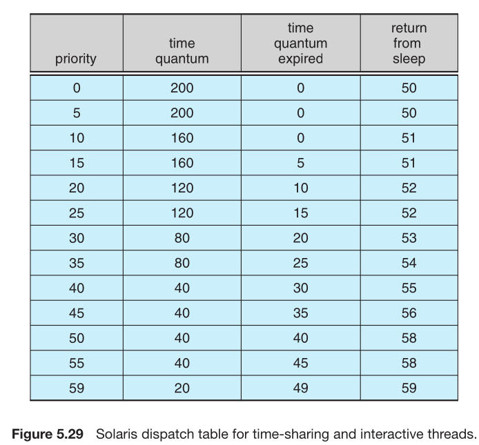

- **Go to Figure 5.29:** This is the dispatch table for the TS and IA classes. It has four columns:
  - **Priority:** The class-specific priority (0-59). A higher number means a higher priority.
  - **Time Quantum:** The time slice assigned to a thread at this priority. Notice priority 0 has a 200 ms quantum, while priority 59 has a 20 ms quantum. This is the inverse relationship in practice.
  - **Time Quantum Expired:** The **new priority** for a thread that **used its entire time slice without blocking**. This thread is considered CPU-intensive, so its priority is **lowered** (e.g., from 50 to 40) to penalize it and benefit interactive tasks.
  - **Return from Sleep:** The **new priority** for a thread that is **waking up** from a sleep (e.g., after an I/O operation). This thread is considered interactive, so its priority is **boosted** to a high value (between 50 and 59) so it can run immediately, providing good response time.

The **Interactive (IA)** class uses the *exact same dispatch table and policy* as the Time-Sharing class. The difference is that it is intended for threads associated with a graphical window, and the system may assign them to a higher initial priority within this framework to ensure a responsive user interface.

#### **The Other Scheduling Classes**

**Real Time (RT) Class**

- Threads in this class have the **highest possible priority** in the system (aside from interrupt threads).
- They will always run before any thread from the TS, IA, SYS, FSS, or FP classes.
- This guarantees a response within a bounded time, which is essential for hard real-time tasks. It is used sparingly.

**System (SYS) Class**

- This class is used for kernel threads (like the scheduler itself or memory management daemons).
- The priorities of SYS threads are **static**; they are set when the thread is created and do not change.
- This class is **reserved for the kernel**; user processes running system calls are *not* in the SYS class.

**Fixed Priority (FP) and Fair Share (FSS) Classes**

- Introduced in Solaris 9.
- **Fixed Priority (FP):** Threads in this class have the same priority range as TS/IA, but their priorities are **not dynamically adjusted** by the scheduler. They remain fixed.
- **Fair Share (FSS):** This class does not use priorities. Instead, it allocates CPU time based on **CPU shares** assigned to a group of processes called a **project**. This ensures that each project gets its entitled fraction of the CPU resources.

#### **Global Priorities and Final Scheduling Decision**

Although each class has its own priorities, the Solaris scheduler combines them into a single, global priority scheme to make its final decision.

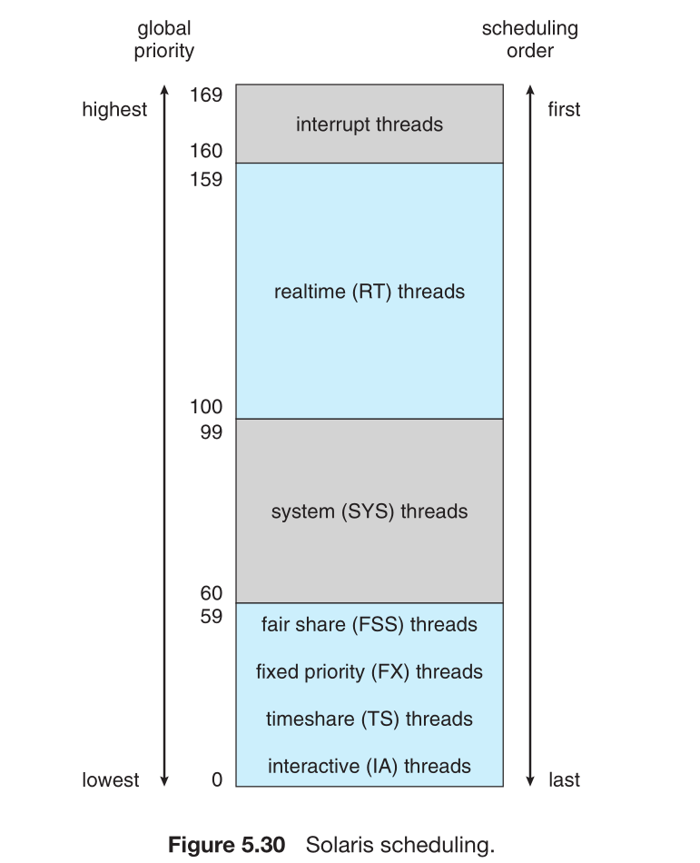

- **Go to Figure 5.30:** This figure shows how all class-specific priorities map onto a global scale.
- The scheduler always picks the runnable thread with the **highest global priority** to run.
- The thread runs until it (1) blocks, (2) uses its time slice, or (3) is preempted by a higher-priority thread.
- If multiple threads have the same global priority, they are scheduled in a **round-robin** fashion from a circular queue.
- **Interrupt Threads:** The kernel has special threads for handling interrupts. These are not in any scheduling class and execute at the very highest global priorities (160-169), ensuring hardware interrupts are serviced immediately.

**Note on Threading Model:** While Solaris traditionally used the many-to-many model, it switched to a one-to-one model starting with Solaris 9, meaning each user thread is mapped directly to a single kernel thread.

## **5.8 Algorithm Evaluation**

#### **The Problem: Choosing a Scheduling Algorithm**

We have learned about many different CPU-scheduling algorithms (FCFS, SJF, Priority, Round Robin, etc.), each with its own parameters and strengths. A fundamental question is: **How do we choose the best one for a particular computer system?** This is a complex problem because there is no single "best" algorithm that fits all scenarios.

#### **Step 1: Define the Evaluation Criteria**

The first and most critical step is to define what "best" means for our specific system. We must establish clear, measurable goals based on the performance criteria from Section 5.2 (CPU utilization, throughput, turnaround time, waiting time, response time).

Our criteria will be a set of requirements that the chosen algorithm must meet. These criteria often involve trade-offs. For example, we might define our goals as:

- **Criterion 1:** Maximize CPU utilization, but with a strict constraint that the **maximum response time for any interactive user must not exceed 300 milliseconds.**
- **Criterion 2:** Maximize overall throughput (number of processes completed per hour), with the additional goal that the average turnaround time is **linearly proportional to the total execution time** of the process. This means that a job that takes twice as long to run should, on average, take twice as long to complete from submission to finish, ensuring predictability.

By defining criteria like this, we move from a vague goal like "make it fast" to a specific, testable set of requirements that we can use to compare different algorithms.

#### **Step 2: Evaluate the Algorithms**

Once we have our criteria, the next step is to evaluate the available scheduling algorithms against them. The following sections will describe the various methods we can use to perform this evaluation, such as deterministic modeling, simulation, and implementation.

### **5.8.1 Deterministic Modeling**

#### **What is Deterministic Modeling?**

Deterministic Modeling is a type of **analytic evaluation**. It is a method where we take a **specific, predetermined workload** (we know exactly when each process arrives and how long its CPU burst will be) and use this to compute the exact performance of different scheduling algorithms for that one scenario.

It answers the question: "For *this exact* set of processes, which algorithm performs best according to a given metric (like average waiting time)?"

#### **A Worked Example**

Consider the following workload. All five processes arrive at time 0 in the order given:

| Process | Burst Time (ms) |
| --- | --- |
| P1 | 10 |
| P2 | 29 |
| P3 | 3 |
| P4 | 7 |
| P5 | 12 |

We will compare the **FCFS**, **SJF (non-preemptive)**, and **RR (quantum = 10 ms)** algorithms based on their **average waiting time**.

**1. First-Come, First-Served (FCFS)** The schedule is simply the order of arrival: P1, P2, P3, P4, P5.

- **Timeline:** `P1 [0-10]` -> `P2 [10-39]` -> `P3 [39-42]` -> `P4 [42-49]` -> `P5 [49-61]`
- **Waiting Time Calculation:**
  - P1: 0 ms
  - P2: 10 ms (waits for P1)
  - P3: 39 ms (waits for P1 + P2)
  - P4: 42 ms (waits for P1 + P2 + P3)
  - P5: 49 ms (waits for P1 + P2 + P3 + P4)
- **Average Waiting Time:** (0 + 10 + 39 + 42 + 49) / 5 = **140 / 5 = 28 ms**

**2. Shortest-Job-First (SJF) - Non-preemptive** The schedule is in order of increasing burst time: P3, P4, P1, P5, P2.

- **Timeline:** `P3 [0-3]` -> `P4 [3-10]` -> `P1 [10-20]` -> `P5 [20-32]` -> `P2 [32-61]`
- **Waiting Time Calculation:**
  - P1: 10 ms (waits for P3 + P4)
  - P2: 32 ms (waits for P3 + P4 + P1 + P5)
  - P3: 0 ms
  - P4: 3 ms (waits for P3)
  - P5: 20 ms (waits for P3 + P4 + P1)
- **Average Waiting Time:** (10 + 32 + 0 + 3 + 20) / 5 = **65 / 5 = 13 ms**

**3. Round Robin (RR) - Quantum = 10 ms** Processes are executed in cycles. The ready queue order at start is P1, P2, P3, P4, P5.

- **Timeline:**
  - **Time 0-10:** P1 runs for its full 10 ms burst and finishes.
  - **Time 10-20:** P2 runs for 10 ms (19 ms remaining).
  - **Time 20-23:** P3 runs for its full 3 ms burst and finishes.
  - **Time 23-30:** P4 runs for its full 7 ms burst and finishes.
  - **Time 30-40:** P5 runs for 10 ms (2 ms remaining).
  - **Time 40-50:** P2 runs for another 10 ms (9 ms remaining).
  - **Time 50-52:** P5 runs for its remaining 2 ms and finishes.
  - **Time 52-61:** P2 runs for its final 9 ms and finishes.
- **Waiting Time Calculation:**
  - P1: 0 ms
  - P2: (10 [wait for P1] + (40-20=20) [wait after 1st run] + (52-50=2) [wait after 2nd run]) = **32 ms**
  - P3: 20 ms (waits for P1 and P2's first time slice)
  - P4: 23 ms (waits for P1, P2's first slice, and P3)
  - P5: (30 [wait for P1, P2, P3, P4] + (50-40=10) [wait after 1st run]) = **40 ms**
- **Average Waiting Time:** (0 + 32 + 20 + 23 + 40) / 5 = **115 / 5 = 23 ms**

**Conclusion for this workload:** SJF gives the best average waiting time (13 ms), followed by RR (23 ms), and then FCFS (28 ms).

#### **Advantages and Disadvantages of Deterministic Modeling**

- **Advantages:**
  - It is **simple and fast**.
  - It provides **exact numbers** for a direct comparison.
  - It is excellent for **illustrating algorithms** and proving properties (e.g., it can be mathematically proven that SJF is optimal for minimizing average waiting time when all jobs are available at time zero).
- **Disadvantages:**
  - It requires **exact, predetermined input data**, which is often not available in real systems where burst times are unpredictable.
  - The results **apply only to the specific workload used**. A different workload might yield completely different results.

**Primary Use:** Deterministic modeling is best used for teaching concepts, providing simple examples, and analyzing closed, repetitive systems where the workload is perfectly known and constant.

### **5.8.2 Queueing Models**

#### **Moving Beyond a Single Snapshot**

In real systems, the set of processes and their burst times are not fixed; they change constantly. Deterministic modeling is too rigid for this environment. Instead, we can use **Queueing Models**, which analyze system performance based on the **probability distributions** of key events rather than fixed values.

- **The Distributions:**
  - **CPU/I/O Burst Distribution:** The frequency of different CPU burst lengths. This is often an **exponential distribution**, which can be described simply by its **mean** (average) value.
  - **Arrival-Time Distribution:** The frequency of new processes arriving in the system.

By knowing these distributions, we can calculate average performance metrics like throughput, CPU utilization, and waiting time for various algorithms.

#### **Modeling the System as a Network of Queues**

In queueing theory, we model a computer system as a network of **servers**, each with its own **queue**.

- The **CPU** is a server, and the **ready queue** is its waiting line.
- Each **I/O device** is a server, and its **device queue** is the waiting line.

Knowing the **arrival rate** (how often processes enter a queue) and the **service rate** (how quickly the server can process them), we can compute important results for any queue, such as:

- Average queue length
- Average waiting time in the queue
- Server utilization

This overall study is known as **queueing-network analysis**.

#### **Little's Formula**

A fundamental and powerful result in queueing theory is **Little's Formula**. It states that for a stable system, the long-term average number of items in a queueing system is equal to the long-term average arrival rate multiplied by the average time an item spends in the system.

For a queue (excluding the item being serviced), it is expressed as: **n = λ × W**

Where:

- **`n`** = average queue length (number of items waiting, not including the one being served).
- **`λ`** (lambda) = average arrival rate (e.g., processes per second).
- **`W`** = average waiting time in the queue.

**Why it's powerful:** Little's formula is **universal**. It holds for **any** scheduling algorithm and **any** arrival distribution.

**Example:** If we know that an average of **7 processes per second (λ)** arrive at the ready queue and that there are normally **14 processes (n)** in the queue (waiting, not running), we can compute the average waiting time:

- n = λ × W
- 14 = 7 × W
- W = 14 / 7 = **2 seconds**

So, the average process waits in the ready queue for 2 seconds.

#### **Limitations of Queueing Analysis**

While powerful, queueing analysis has significant limitations:

1. **Mathematical Complexity:** The math becomes very difficult for complicated scheduling algorithms and realistic, complex distributions.
2. **Oversimplified Assumptions:** To make the math tractable, models often use mathematically convenient distributions (like exponential) that may not perfectly reflect real-world behavior.
3. **Independent Assumptions:** The models often require assumptions that may not be entirely accurate, such assuming arrivals are independent of the current system state.
4. **Approximate Results:** Because of the simplifications and assumptions, the results from a queueing model are often **approximations** of real-system behavior, and their accuracy can sometimes be questionable.

Despite these limitations, queueing models provide invaluable insights for understanding the general relationships between arrival rate, queue length, and waiting time, and for making high-level comparisons between scheduling strategies.

### **5.8.3 Simulations**

#### **A More Accurate Evaluation Method**

To get a more precise and realistic evaluation of scheduling algorithms than analytical models can provide, we use **simulations**. A simulation involves creating a **software model** of a computer system.

- **How it works:** The programmer creates data structures that represent the key components of the system, such as the CPU, I/O devices, the ready queue, and the processes. The simulation is controlled by a variable that acts as a **clock**.
- **Process:** As the clock advances, the simulator updates the system state to reflect everything that happens: processes arriving, the scheduler making decisions, processes running on the CPU, and processes performing I/O.
- **Output:** Throughout the simulation, the program collects detailed **statistics** on performance metrics (like average waiting time, throughput, etc.) for the algorithm being tested.